# Supervised Learning : Exploring Dichotomization Thresholding Strategies for Optimal Classification

John Pauline Pineda

February 4, 2023

# **1. Table of Contents**

This project explores different dichotomization thresholding strategies for optimally classifying categorical responses using various helpful packages in **R**. Using a **Logistic Regression** model structure, threshold criteria applied in the analysis to support optimal class prediction included **Minimum Sensitivity**, **Minimum Specificity**, **Maximum Product of Specificity and Sensitivity**, **ROC Curve Point Closest to Point (0,1)**, **Sensitivity Equals Specificity**, **Youden’s Index**, **Maximum Efficiency**, **Minimization of Most Frequent Error**, **Maximum Diagnostic Odds Ratio**, **Maximum Kappa**, **Minimum Negative Predictive Value**, **Minimum Positive Predictive Value**, **Negative Predictive Value Equals Positive Predictive Value**, **Minimum P-Value** and **ROC Curve Point Closest to Observed Prevalence**. The optimal thresholds determined for all criteria were compared and evaluated in terms of their relevance to the sensitivity and specificity objectives of the classification problem at hand. All results were consolidated in a **Summary** presented at the end of the document.  
Dichotomization thresholding is a process applied during classification model development aimed at selecting a cutpoint to define the positive and negative categories from a numeric input. The criteria applied in this study (mostly contained in the **OptimalCutpoints** package) attempt to implement various approaches for selecting optimal thresholds under various objectives including methods based on standard diagnostic test accuracy measures (Sensitivity, Specificity, Predictive Values and Diagnostic Likelihood Ratios) and cost-benefit analysis, among others.

## 1.1 Sample Data

The **Solubility** dataset from the **AppliedPredictiveModeling** package was used for this illustrated example. The original numeric response was transformed to simulate a dichotomous categorical variable. Other original predictors were removed from the dataset leaving only a subset of numeric predictors used during the analysis.  
Preliminary dataset assessment:  
**[A]** 951 rows (observations)  
**[A.1]** Train Set = 951 observations  
**[B]** 5 columns (variables)  
**[B.1]** 1/5 response = Log_Solubility_Class variable (factor)  
**[B.1.1]** Levels = Log_Solubility_Class=Low < Log_Solubility_Class=High  
**[B.2]** 4/5 predictors = All remaining variables (0/4 factor + 4/4 numeric)

**Code Chunk | Output**

```r
##################################
# Loading R libraries
##################################
library(AppliedPredictiveModeling)
library(caret)
library(rpart)
library(lattice)
library(dplyr)
library(tidyr)
library(moments)
library(skimr)
library(RANN)
library(pls)
library(corrplot)
library(tidyverse)
library(lares)
library(DMwR)
library(gridExtra)
library(rattle)
library(rpart.plot)
library(RColorBrewer)
library(stats)
library(nnet)
library(elasticnet)
library(earth)
library(party)
library(kernlab)
library(randomForest)
library(Cubist)
library(pROC)
library(mda)
library(klaR)
library(pamr)
library(OptimalCutpoints)
library(broom)
library(PRROC)

##################################
# Loading source and
# formulating the train set
##################################
data(solubility)
Solubility_Train <- as.data.frame(cbind(solTrainY,solTrainX))

##################################
# Applying dichotomization and
# defining the response variable
##################################
Solubility_Train$Log_Solubility_Class <- ifelse(Solubility_Train$solTrainY<mean(Solubility_Train$solTrainY),
                                                "Low","High")
Solubility_Train$Log_Solubility_Class <- factor(Solubility_Train$Log_Solubility_Class,
                                                levels = c("Low","High"))

Solubility_Train$solTrainY <- NULL

##################################
# Filtering in a subset of variables
# for the analysis
##################################
Solubility_Train <- Solubility_Train[,c("MolWeight",
                                        "NumCarbon",
                                        "NumHalogen",
                                        "HydrophilicFactor",
                                        "Log_Solubility_Class")]

##################################
# Performing a general exploration of the train set
##################################
dim(Solubility_Train)
```

```
## [1] 951   5
```

```r
str(Solubility_Train)
```

```
## 'data.frame':    951 obs. of  5 variables:
##  $ MolWeight           : num  208 366 206 136 230 ...
##  $ NumCarbon           : int  14 21 13 10 9 10 17 12 22 14 ...
##  $ NumHalogen          : int  0 0 0 0 1 2 2 0 1 0 ...
##  $ HydrophilicFactor   : num  -0.856 -0.37 -0.33 -0.96 -0.069 -0.651 -0.729 -0.835 0.194 0.353 ...
##  $ Log_Solubility_Class: Factor w/ 2 levels "Low","High": 1 1 1 1 1 1 1 1 1 1 ...
```

```r
summary(Solubility_Train)
```

```
##    MolWeight        NumCarbon        NumHalogen      HydrophilicFactor
##  Min.   : 46.09   Min.   : 1.000   Min.   : 0.0000   Min.   :-0.98500
##  1st Qu.:122.61   1st Qu.: 6.000   1st Qu.: 0.0000   1st Qu.:-0.76300
##  Median :179.23   Median : 9.000   Median : 0.0000   Median :-0.31400
##  Mean   :201.65   Mean   : 9.893   Mean   : 0.6982   Mean   :-0.02059
##  3rd Qu.:264.34   3rd Qu.:12.000   3rd Qu.: 1.0000   3rd Qu.: 0.31300
##  Max.   :665.81   Max.   :33.000   Max.   :10.0000   Max.   :13.48300
##  Log_Solubility_Class
##  Low :427
##  High:524
##
##
##
##
```

```r
##################################
# Formulating a data type assessment summary
##################################
PDA <- Solubility_Train
(PDA.Summary <- data.frame(
  Column.Index=c(1:length(names(PDA))),
  Column.Name= names(PDA),
  Column.Type=sapply(PDA, function(x) class(x)),
  row.names=NULL)
)
```

```
##   Column.Index          Column.Name Column.Type
## 1            1            MolWeight     numeric
## 2            2            NumCarbon     integer
## 3            3           NumHalogen     integer
## 4            4    HydrophilicFactor     numeric
## 5            5 Log_Solubility_Class      factor
```

## 1.2 Data Quality Assessment

**Code Chunk | Output**

```r
##################################
# Loading dataset
##################################
DQA <- Solubility_Train

##################################
# Formulating an overall data quality assessment summary
##################################
(DQA.Summary <- data.frame(
  Column.Index=c(1:length(names(DQA))),
  Column.Name= names(DQA),
  Column.Type=sapply(DQA, function(x) class(x)),
  Row.Count=sapply(DQA, function(x) nrow(DQA)),
  NA.Count=sapply(DQA,function(x)sum(is.na(x))),
  Fill.Rate=sapply(DQA,function(x)format(round((sum(!is.na(x))/nrow(DQA)),3),nsmall=3)),
  row.names=NULL)
)
```

```
##   Column.Index          Column.Name Column.Type Row.Count NA.Count Fill.Rate
## 1            1            MolWeight     numeric       951        0     1.000
## 2            2            NumCarbon     integer       951        0     1.000
## 3            3           NumHalogen     integer       951        0     1.000
## 4            4    HydrophilicFactor     numeric       951        0     1.000
## 5            5 Log_Solubility_Class      factor       951        0     1.000
```

```r
##################################
# Listing all predictors
##################################
DQA.Predictors <- DQA[,!names(DQA) %in% c("Log_Solubility_Class")]

##################################
# Listing all numeric predictors
##################################
DQA.Predictors.Numeric <- DQA.Predictors[,sapply(DQA.Predictors, is.numeric)]

if (length(names(DQA.Predictors.Numeric))>0) {
    print(paste0("There are ",
               (length(names(DQA.Predictors.Numeric))),
               " numeric predictor variable(s)."))
} else {
  print("There are no numeric predictor variables.")
}
```

```
## [1] "There are 4 numeric predictor variable(s)."
```

```r
##################################
# Listing all factor predictors
##################################
DQA.Predictors.Factor <- DQA.Predictors[,sapply(DQA.Predictors, is.factor)]

if (length(names(DQA.Predictors.Factor))>0) {
    print(paste0("There are ",
               (length(names(DQA.Predictors.Factor))),
               " factor predictor variable(s)."))
} else {
  print("There are no factor predictor variables.")
}
```

```
## [1] "There are no factor predictor variables."
```

```r
##################################
# Formulating a data quality assessment summary for factor predictors
##################################
if (length(names(DQA.Predictors.Factor))>0) {

  ##################################
  # Formulating a function to determine the first mode
  ##################################
  FirstModes <- function(x) {
    ux <- unique(na.omit(x))
    tab <- tabulate(match(x, ux))
    ux[tab == max(tab)]
  }

  ##################################
  # Formulating a function to determine the second mode
  ##################################
  SecondModes <- function(x) {
    ux <- unique(na.omit(x))
    tab <- tabulate(match(x, ux))
    fm = ux[tab == max(tab)]
    sm = x[!(x %in% fm)]
    usm <- unique(sm)
    tabsm <- tabulate(match(sm, usm))
    ifelse(is.na(usm[tabsm == max(tabsm)])==TRUE,
           return("x"),
           return(usm[tabsm == max(tabsm)]))
  }

  (DQA.Predictors.Factor.Summary <- data.frame(
  Column.Name= names(DQA.Predictors.Factor),
  Column.Type=sapply(DQA.Predictors.Factor, function(x) class(x)),
  Unique.Count=sapply(DQA.Predictors.Factor, function(x) length(unique(x))),
  First.Mode.Value=sapply(DQA.Predictors.Factor, function(x) as.character(FirstModes(x)[1])),
  Second.Mode.Value=sapply(DQA.Predictors.Factor, function(x) as.character(SecondModes(x)[1])),
  First.Mode.Count=sapply(DQA.Predictors.Factor, function(x) sum(na.omit(x) == FirstModes(x)[1])),
  Second.Mode.Count=sapply(DQA.Predictors.Factor, function(x) sum(na.omit(x) == SecondModes(x)[1])),
  Unique.Count.Ratio=sapply(DQA.Predictors.Factor, function(x) format(round((length(unique(x))/nrow(DQA.Predictors.Factor)),3), nsmall=3)),
  First.Second.Mode.Ratio=sapply(DQA.Predictors.Factor, function(x) format(round((sum(na.omit(x) == FirstModes(x)[1])/sum(na.omit(x) == SecondModes(x)[1])),3), nsmall=3)),
  row.names=NULL)
  )

}

##################################
# Formulating a data quality assessment summary for numeric predictors
##################################
if (length(names(DQA.Predictors.Numeric))>0) {

  ##################################
  # Formulating a function to determine the first mode
  ##################################
  FirstModes <- function(x) {
    ux <- unique(na.omit(x))
    tab <- tabulate(match(x, ux))
    ux[tab == max(tab)]
  }

  ##################################
  # Formulating a function to determine the second mode
  ##################################
  SecondModes <- function(x) {
    ux <- unique(na.omit(x))
    tab <- tabulate(match(x, ux))
    fm = ux[tab == max(tab)]
    sm = na.omit(x)[!(na.omit(x) %in% fm)]
    usm <- unique(sm)
    tabsm <- tabulate(match(sm, usm))
    ifelse(is.na(usm[tabsm == max(tabsm)])==TRUE,
           return(0.00001),
           return(usm[tabsm == max(tabsm)]))
  }

  (DQA.Predictors.Numeric.Summary <- data.frame(
  Column.Name= names(DQA.Predictors.Numeric),
  Column.Type=sapply(DQA.Predictors.Numeric, function(x) class(x)),
  Unique.Count=sapply(DQA.Predictors.Numeric, function(x) length(unique(x))),
  Unique.Count.Ratio=sapply(DQA.Predictors.Numeric, function(x) format(round((length(unique(x))/nrow(DQA.Predictors.Numeric)),3), nsmall=3)),
  First.Mode.Value=sapply(DQA.Predictors.Numeric, function(x) format(round((FirstModes(x)[1]),3),nsmall=3)),
  Second.Mode.Value=sapply(DQA.Predictors.Numeric, function(x) format(round((SecondModes(x)[1]),3),nsmall=3)),
  First.Mode.Count=sapply(DQA.Predictors.Numeric, function(x) sum(na.omit(x) == FirstModes(x)[1])),
  Second.Mode.Count=sapply(DQA.Predictors.Numeric, function(x) sum(na.omit(x) == SecondModes(x)[1])),
  First.Second.Mode.Ratio=sapply(DQA.Predictors.Numeric, function(x) format(round((sum(na.omit(x) == FirstModes(x)[1])/sum(na.omit(x) == SecondModes(x)[1])),3), nsmall=3)),
  Minimum=sapply(DQA.Predictors.Numeric, function(x) format(round(min(x,na.rm = TRUE),3), nsmall=3)),
  Mean=sapply(DQA.Predictors.Numeric, function(x) format(round(mean(x,na.rm = TRUE),3), nsmall=3)),
  Median=sapply(DQA.Predictors.Numeric, function(x) format(round(median(x,na.rm = TRUE),3), nsmall=3)),
  Maximum=sapply(DQA.Predictors.Numeric, function(x) format(round(max(x,na.rm = TRUE),3), nsmall=3)),
  Skewness=sapply(DQA.Predictors.Numeric, function(x) format(round(skewness(x,na.rm = TRUE),3), nsmall=3)),
  Kurtosis=sapply(DQA.Predictors.Numeric, function(x) format(round(kurtosis(x,na.rm = TRUE),3), nsmall=3)),
  Percentile25th=sapply(DQA.Predictors.Numeric, function(x) format(round(quantile(x,probs=0.25,na.rm = TRUE),3), nsmall=3)),
  Percentile75th=sapply(DQA.Predictors.Numeric, function(x) format(round(quantile(x,probs=0.75,na.rm = TRUE),3), nsmall=3)),
  row.names=NULL)
  )

}
```

```
##         Column.Name Column.Type Unique.Count Unique.Count.Ratio
## 1         MolWeight     numeric          646              0.679
## 2         NumCarbon     integer           28              0.029
## 3        NumHalogen     integer           11              0.012
## 4 HydrophilicFactor     numeric          369              0.388
##   First.Mode.Value Second.Mode.Value First.Mode.Count Second.Mode.Count
## 1          102.200           116.230               16                14
## 2            6.000             7.000              105                97
## 3            0.000             1.000              685               107
## 4           -0.828            -0.158               21                20
##   First.Second.Mode.Ratio Minimum    Mean  Median Maximum Skewness Kurtosis
## 1                   1.143  46.090 201.654 179.230 665.810    0.988    3.945
## 2                   1.082   1.000   9.893   9.000  33.000    0.927    3.616
## 3                   6.402   0.000   0.698   0.000  10.000    2.691   10.808
## 4                   1.050  -0.985  -0.021  -0.314  13.483    3.404   27.504
##   Percentile25th Percentile75th
## 1        122.605        264.340
## 2          6.000         12.000
## 3          0.000          1.000
## 4         -0.763          0.313
```

```r
##################################
# Identifying potential data quality issues
##################################

##################################
# Checking for missing observations
##################################
if ((nrow(DQA.Summary[DQA.Summary$NA.Count>0,]))>0){
  print(paste0("Missing observations noted for ",
               (nrow(DQA.Summary[DQA.Summary$NA.Count>0,])),
               " variable(s) with NA.Count>0 and Fill.Rate<1.0."))
  DQA.Summary[DQA.Summary$NA.Count>0,]
} else {
  print("No missing observations noted.")
}
```

```
## [1] "No missing observations noted."
```

```r
##################################
# Checking for zero or near-zero variance predictors
##################################
if (length(names(DQA.Predictors.Factor))==0) {
  print("No factor predictors noted.")
} else if (nrow(DQA.Predictors.Factor.Summary[as.numeric(as.character(DQA.Predictors.Factor.Summary$First.Second.Mode.Ratio))>5,])>0){
  print(paste0("Low variance observed for ",
               (nrow(DQA.Predictors.Factor.Summary[as.numeric(as.character(DQA.Predictors.Factor.Summary$First.Second.Mode.Ratio))>5,])),
               " factor variable(s) with First.Second.Mode.Ratio>5."))
  DQA.Predictors.Factor.Summary[as.numeric(as.character(DQA.Predictors.Factor.Summary$First.Second.Mode.Ratio))>5,]
} else {
  print("No low variance factor predictors due to high first-second mode ratio noted.")
}
```

```
## [1] "No factor predictors noted."
```

```r
if (length(names(DQA.Predictors.Numeric))==0) {
  print("No numeric predictors noted.")
} else if (nrow(DQA.Predictors.Numeric.Summary[as.numeric(as.character(DQA.Predictors.Numeric.Summary$First.Second.Mode.Ratio))>5,])>0){
  print(paste0("Low variance observed for ",
               (nrow(DQA.Predictors.Numeric.Summary[as.numeric(as.character(DQA.Predictors.Numeric.Summary$First.Second.Mode.Ratio))>5,])),
               " numeric variable(s) with First.Second.Mode.Ratio>5."))
  DQA.Predictors.Numeric.Summary[as.numeric(as.character(DQA.Predictors.Numeric.Summary$First.Second.Mode.Ratio))>5,]
} else {
  print("No low variance numeric predictors due to high first-second mode ratio noted.")
}
```

```
## [1] "Low variance observed for 1 numeric variable(s) with First.Second.Mode.Ratio>5."
```

```
##   Column.Name Column.Type Unique.Count Unique.Count.Ratio First.Mode.Value
## 3  NumHalogen     integer           11              0.012            0.000
##   Second.Mode.Value First.Mode.Count Second.Mode.Count First.Second.Mode.Ratio
## 3             1.000              685               107                   6.402
##   Minimum  Mean Median Maximum Skewness Kurtosis Percentile25th Percentile75th
## 3   0.000 0.698  0.000  10.000    2.691   10.808          0.000          1.000
```

```r
if (length(names(DQA.Predictors.Numeric))==0) {
  print("No numeric predictors noted.")
} else if (nrow(DQA.Predictors.Numeric.Summary[as.numeric(as.character(DQA.Predictors.Numeric.Summary$Unique.Count.Ratio))<0.01,])>0){
  print(paste0("Low variance observed for ",
               (nrow(DQA.Predictors.Numeric.Summary[as.numeric(as.character(DQA.Predictors.Numeric.Summary$Unique.Count.Ratio))<0.01,])),
               " numeric variable(s) with Unique.Count.Ratio<0.01."))
  DQA.Predictors.Numeric.Summary[as.numeric(as.character(DQA.Predictors.Numeric.Summary$Unique.Count.Ratio))<0.01,]
} else {
  print("No low variance numeric predictors due to low unique count ratio noted.")
}
```

```
## [1] "No low variance numeric predictors due to low unique count ratio noted."
```

```r
##################################
# Checking for skewed predictors
##################################
if (length(names(DQA.Predictors.Numeric))==0) {
  print("No numeric predictors noted.")
} else if (nrow(DQA.Predictors.Numeric.Summary[as.numeric(as.character(DQA.Predictors.Numeric.Summary$Skewness))>3 |
                                               as.numeric(as.character(DQA.Predictors.Numeric.Summary$Skewness))<(-3),])>0){
  print(paste0("High skewness observed for ",
  (nrow(DQA.Predictors.Numeric.Summary[as.numeric(as.character(DQA.Predictors.Numeric.Summary$Skewness))>3 |
                                               as.numeric(as.character(DQA.Predictors.Numeric.Summary$Skewness))<(-3),])),
  " numeric variable(s) with Skewness>3 or Skewness<(-3)."))
  DQA.Predictors.Numeric.Summary[as.numeric(as.character(DQA.Predictors.Numeric.Summary$Skewness))>3 |
                                 as.numeric(as.character(DQA.Predictors.Numeric.Summary$Skewness))<(-3),]
} else {
  print("No skewed numeric predictors noted.")
}
```

```
## [1] "High skewness observed for 1 numeric variable(s) with Skewness>3 or Skewness<(-3)."
```

```
##         Column.Name Column.Type Unique.Count Unique.Count.Ratio
## 4 HydrophilicFactor     numeric          369              0.388
##   First.Mode.Value Second.Mode.Value First.Mode.Count Second.Mode.Count
## 4           -0.828            -0.158               21                20
##   First.Second.Mode.Ratio Minimum   Mean Median Maximum Skewness Kurtosis
## 4                   1.050  -0.985 -0.021 -0.314  13.483    3.404   27.504
##   Percentile25th Percentile75th
## 4         -0.763          0.313
```

## 1.3 Data Preprocessing

### 1.3.1 Outlier

**Code Chunk | Output**

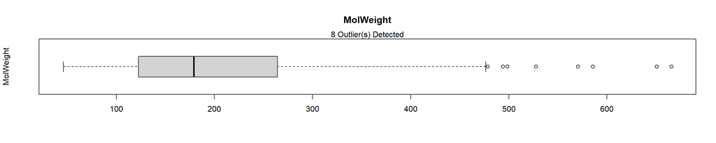

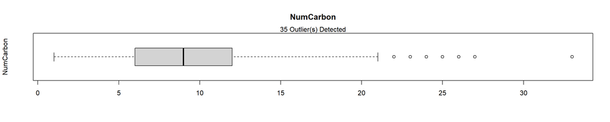

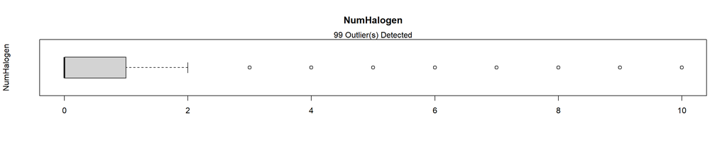

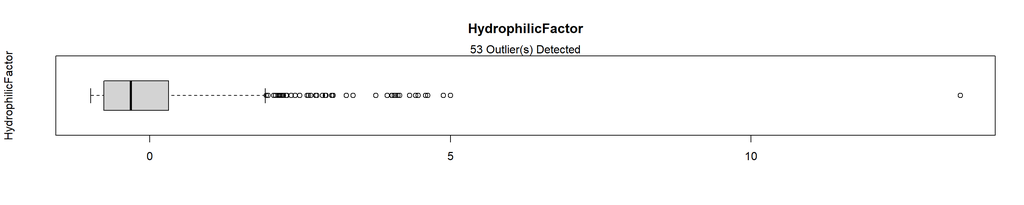

```r
##################################
# Loading dataset
##################################
DPA <- Solubility_Train

##################################
# Listing all predictors
##################################
DPA.Predictors <- DPA[,!names(DPA) %in% c("Log_Solubility_Class")]

##################################
# Listing all numeric predictors
##################################
DPA.Predictors.Numeric <- DPA.Predictors[,sapply(DPA.Predictors, is.numeric)]

##################################
# Identifying outliers for the numeric predictors
##################################
OutlierCountList <- c()

for (i in 1:ncol(DPA.Predictors.Numeric)) {
  Outliers <- boxplot.stats(DPA.Predictors.Numeric[,i])$out
  OutlierCount <- length(Outliers)
  OutlierCountList <- append(OutlierCountList,OutlierCount)
  OutlierIndices <- which(DPA.Predictors.Numeric[,i] %in% c(Outliers))
  boxplot(DPA.Predictors.Numeric[,i],
          ylab = names(DPA.Predictors.Numeric)[i],
          main = names(DPA.Predictors.Numeric)[i],
          horizontal=TRUE)
  mtext(paste0(OutlierCount, " Outlier(s) Detected"))
}
```

```r
OutlierCountSummary <- as.data.frame(cbind(names(DPA.Predictors.Numeric),(OutlierCountList)))
names(OutlierCountSummary) <- c("NumericPredictors","OutlierCount")
OutlierCountSummary$OutlierCount <- as.numeric(as.character(OutlierCountSummary$OutlierCount))
NumericPredictorWithOutlierCount <- nrow(OutlierCountSummary[OutlierCountSummary$OutlierCount>0,])
print(paste0(NumericPredictorWithOutlierCount, " numeric variable(s) were noted with outlier(s)." ))
```

```
## [1] "4 numeric variable(s) were noted with outlier(s)."
```

```r
##################################
# Gathering descriptive statistics
##################################
(DPA_Skimmed <- skim(DPA.Predictors.Numeric))
```

Data summary

| Name | DPA.Predictors.Numeric |
| --- | --- |
| Number of rows | 951 |
| Number of columns | 4 |
| _______________________ |  |
| Column type frequency: |  |
| numeric | 4 |
| ________________________ |  |
| Group variables | None |

**Variable type: numeric**

| skim_variable | n_missing | complete_rate | mean | sd | p0 | p25 | p50 | p75 | p100 | hist |
| --- | --- | --- | --- | --- | --- | --- | --- | --- | --- | --- |
| MolWeight | 0 | 1 | 201.65 | 97.91 | 46.09 | 122.60 | 179.23 | 264.34 | 665.81 | ▇▆▂▁▁ |
| NumCarbon | 0 | 1 | 9.89 | 5.29 | 1.00 | 6.00 | 9.00 | 12.00 | 33.00 | ▇▇▃▁▁ |
| NumHalogen | 0 | 1 | 0.70 | 1.47 | 0.00 | 0.00 | 0.00 | 1.00 | 10.00 | ▇▁▁▁▁ |
| HydrophilicFactor | 0 | 1 | -0.02 | 1.13 | -0.98 | -0.76 | -0.31 | 0.31 | 13.48 | ▇▁▁▁▁ |

```r
###################################
# Verifying the data dimensions
###################################
dim(DPA.Predictors.Numeric)
```

```
## [1] 951   4
```

### 1.3.2 Zero and Near-Zero Variance

**[A]** Low variance noted for any variable from the previous data quality assessment using a lower threshold.  
**[B]** No low variance noted for any variables using a preprocessing summary from the **caret** package. The nearZeroVar method using both the freqCut and uniqueCut criteria set at 95/5 and 10, respectively, were applied on the dataset.

**Code Chunk | Output**

```r
##################################
# Loading dataset
##################################
DPA <- Solubility_Train

##################################
# Gathering descriptive statistics
##################################
(DPA_Skimmed <- skim(DPA))
```

Data summary

| Name | DPA |
| --- | --- |
| Number of rows | 951 |
| Number of columns | 5 |
| _______________________ |  |
| Column type frequency: |  |
| factor | 1 |
| numeric | 4 |
| ________________________ |  |
| Group variables | None |

**Variable type: factor**

| skim_variable | n_missing | complete_rate | ordered | n_unique | top_counts |
| --- | --- | --- | --- | --- | --- |
| Log_Solubility_Class | 0 | 1 | FALSE | 2 | Hig: 524, Low: 427 |

**Variable type: numeric**

| skim_variable | n_missing | complete_rate | mean | sd | p0 | p25 | p50 | p75 | p100 | hist |
| --- | --- | --- | --- | --- | --- | --- | --- | --- | --- | --- |
| MolWeight | 0 | 1 | 201.65 | 97.91 | 46.09 | 122.60 | 179.23 | 264.34 | 665.81 | ▇▆▂▁▁ |
| NumCarbon | 0 | 1 | 9.89 | 5.29 | 1.00 | 6.00 | 9.00 | 12.00 | 33.00 | ▇▇▃▁▁ |
| NumHalogen | 0 | 1 | 0.70 | 1.47 | 0.00 | 0.00 | 0.00 | 1.00 | 10.00 | ▇▁▁▁▁ |
| HydrophilicFactor | 0 | 1 | -0.02 | 1.13 | -0.98 | -0.76 | -0.31 | 0.31 | 13.48 | ▇▁▁▁▁ |

```r
##################################
# Identifying columns with low variance
###################################
DPA_LowVariance <- nearZeroVar(DPA,
                               freqCut = 95/5,
                               uniqueCut = 10,
                               saveMetrics= TRUE)
(DPA_LowVariance[DPA_LowVariance$nzv,])
```

```
## [1] freqRatio     percentUnique zeroVar       nzv
## <0 rows> (or 0-length row.names)
```

```r
if ((nrow(DPA_LowVariance[DPA_LowVariance$nzv,]))==0){

  print("No low variance predictors noted.")

} else {

  print(paste0("Low variance observed for ",
               (nrow(DPA_LowVariance[DPA_LowVariance$nzv,])),
               " numeric variable(s) with First.Second.Mode.Ratio>4 and Unique.Count.Ratio<0.10."))

  DPA_LowVarianceForRemoval <- (nrow(DPA_LowVariance[DPA_LowVariance$nzv,]))

  print(paste0("Low variance can be resolved by removing ",
               (nrow(DPA_LowVariance[DPA_LowVariance$nzv,])),
               " numeric variable(s)."))

  for (j in 1:DPA_LowVarianceForRemoval) {
  DPA_LowVarianceRemovedVariable <- rownames(DPA_LowVariance[DPA_LowVariance$nzv,])[j]
  print(paste0("Variable ",
               j,
               " for removal: ",
               DPA_LowVarianceRemovedVariable))
  }

  DPA %>%
  skim() %>%
  dplyr::filter(skim_variable %in% rownames(DPA_LowVariance[DPA_LowVariance$nzv,]))

  ##################################
  # Filtering out columns with low variance
  #################################
  DPA_ExcludedLowVariance <- DPA[,!names(DPA) %in% rownames(DPA_LowVariance[DPA_LowVariance$nzv,])]

  ##################################
  # Gathering descriptive statistics
  ##################################
  (DPA_ExcludedLowVariance_Skimmed <- skim(DPA_ExcludedLowVariance))
}
```

```
## [1] "No low variance predictors noted."
```

### 1.3.3 Collinearity

**[A]** No high correlation > 95% were noted for any 2 variable pairs as confirmed using the preprocessing summaries from the **caret** and **lares** packages.

**Code Chunk | Output**

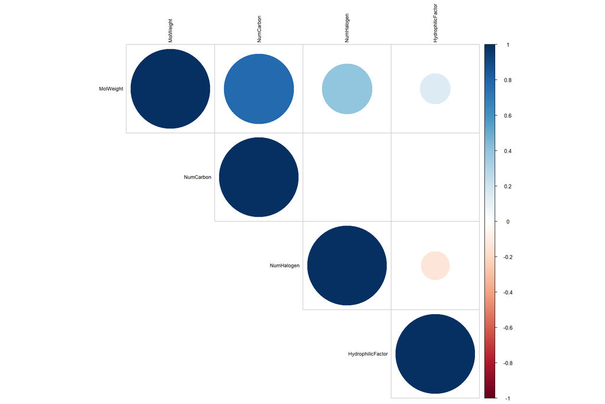

```r
##################################
# Loading dataset
##################################
DPA <- Solubility_Train

##################################
# Listing all predictors
##################################
DPA.Predictors <- DPA[,!names(DPA) %in% c("Log_Solubility_Class")]

##################################
# Listing all numeric predictors
##################################
DPA.Predictors.Numeric <- DPA.Predictors[,sapply(DPA.Predictors, is.numeric)]

##################################
# Visualizing pairwise correlation between predictors
##################################
DPA_CorrelationTest <- cor.mtest(DPA.Predictors.Numeric,
                       method = "pearson",
                       conf.level = .95)

corrplot(cor(DPA.Predictors.Numeric,
             method = "pearson",
             use="pairwise.complete.obs"),
         method = "circle",
         type = "upper",
         order = "original",
         tl.col = "black",
         tl.cex = 0.75,
         tl.srt = 90,
         sig.level = 0.05,
         p.mat = DPA_CorrelationTest$p,
         insig = "blank")
```

```r
##################################
# Identifying the highly correlated variables
##################################
DPA_Correlation <-  cor(DPA.Predictors.Numeric,
                        method = "pearson",
                        use="pairwise.complete.obs")
(DPA_HighlyCorrelatedCount <- sum(abs(DPA_Correlation[upper.tri(DPA_Correlation)]) > 0.95))
```

```
## [1] 0
```

```r
if (DPA_HighlyCorrelatedCount == 0) {
  print("No highly correlated predictors noted.")
} else {
  print(paste0("High correlation observed for ",
               (DPA_HighlyCorrelatedCount),
               " pairs of numeric variable(s) with Correlation.Coefficient>0.95."))

  (DPA_HighlyCorrelatedPairs <- corr_cross(DPA.Predictors.Numeric,
  max_pvalue = 0.05,
  top = DPA_HighlyCorrelatedCount,
  rm.na = TRUE,
  grid = FALSE
))

}
```

```
## [1] "No highly correlated predictors noted."
```

```r
if (DPA_HighlyCorrelatedCount > 0) {
  DPA_HighlyCorrelated <- findCorrelation(DPA_Correlation, cutoff = 0.95)

  (DPA_HighlyCorrelatedForRemoval <- length(DPA_HighlyCorrelated))

  print(paste0("High correlation can be resolved by removing ",
               (DPA_HighlyCorrelatedForRemoval),
               " numeric variable(s)."))

  for (j in 1:DPA_HighlyCorrelatedForRemoval) {
  DPA_HighlyCorrelatedRemovedVariable <- colnames(DPA.Predictors.Numeric)[DPA_HighlyCorrelated[j]]
  print(paste0("Variable ",
               j,
               " for removal: ",
               DPA_HighlyCorrelatedRemovedVariable))
  }

  ##################################
  # Filtering out columns with high correlation
  #################################
  DPA_ExcludedHighCorrelation <- DPA[,-DPA_HighlyCorrelated]

  ##################################
  # Gathering descriptive statistics
  ##################################
  (DPA_ExcludedHighCorrelation_Skimmed <- skim(DPA_ExcludedHighCorrelation))

}
```

### 1.3.4 Linear Dependencies

**[A]** No linear dependencies noted for any subsets of variables using the preprocessing summary from the **caret** package applying the findLinearCombos method which utilizes the QR decomposition of a matrix to enumerate sets of linear combinations (if they exist).

**Code Chunk | Output**

```r
##################################
# Loading dataset
##################################
DPA <- Solubility_Train

##################################
# Listing all predictors
##################################
DPA.Predictors <- DPA[,!names(DPA) %in% c("Log_Solubility_Class")]

##################################
# Listing all numeric predictors
##################################
DPA.Predictors.Numeric <- DPA.Predictors[,sapply(DPA.Predictors, is.numeric)]

##################################
# Identifying the linearly dependent variables
##################################
DPA_LinearlyDependent <- findLinearCombos(DPA.Predictors.Numeric)

(DPA_LinearlyDependentCount <- length(DPA_LinearlyDependent$linearCombos))
```

```
## [1] 0
```

```r
if (DPA_LinearlyDependentCount == 0) {
  print("No linearly dependent predictors noted.")
} else {
  print(paste0("Linear dependency observed for ",
               (DPA_LinearlyDependentCount),
               " subset(s) of numeric variable(s)."))

  for (i in 1:DPA_LinearlyDependentCount) {
    DPA_LinearlyDependentSubset <- colnames(DPA.Predictors.Numeric)[DPA_LinearlyDependent$linearCombos[[i]]]
    print(paste0("Linear dependent variable(s) for subset ",
                 i,
                 " include: ",
                 DPA_LinearlyDependentSubset))
  }

}
```

```
## [1] "No linearly dependent predictors noted."
```

```r
##################################
# Identifying the linearly dependent variables for removal
##################################

if (DPA_LinearlyDependentCount > 0) {
  DPA_LinearlyDependent <- findLinearCombos(DPA.Predictors.Numeric)

  DPA_LinearlyDependentForRemoval <- length(DPA_LinearlyDependent$remove)

  print(paste0("Linear dependency can be resolved by removing ",
               (DPA_LinearlyDependentForRemoval),
               " numeric variable(s)."))

  for (j in 1:DPA_LinearlyDependentForRemoval) {
  DPA_LinearlyDependentRemovedVariable <- colnames(DPA.Predictors.Numeric)[DPA_LinearlyDependent$remove[j]]
  print(paste0("Variable ",
               j,
               " for removal: ",
               DPA_LinearlyDependentRemovedVariable))
  }

  ##################################
  # Filtering out columns with linear dependency
  #################################
  DPA_ExcludedLinearlyDependent <- DPA[,-DPA_LinearlyDependent$remove]

  ##################################
  # Gathering descriptive statistics
  ##################################
  (DPA_ExcludedLinearlyDependent_Skimmed <- skim(DPA_ExcludedLinearlyDependent))

}
```

### 1.3.5 Pre-Processed Dataset

**[A]** 951 rows (observations)  
**[A.1]** Train Set = 951 observations  
**[B]** 5 columns (variables)  
**[B.1]** 1/5 response = Log_Solubility_Class variable (factor)  
**[B.1.1]** Levels = Log_Solubility_Class=Low < Log_Solubility_Class=High  
**[B.2]** 4/5 predictors = All remaining variables (0/4 factor + 4/4 numeric)  
**[C]** Pre-processing actions applied:  
**[C.1]** No predictors removed due to zero or near-zero variance, high correlation or linear dependencies

**Code Chunk | Output**

```r
##################################
# Creating the pre-modelling
# train set
##################################
PMA_PreModelling_Train <- Solubility_Train

##################################
# Gathering descriptive statistics
##################################
(PMA_PreModelling_Train_Skimmed <- skim(PMA_PreModelling_Train))
```

Data summary

| Name | PMA_PreModelling_Train |
| --- | --- |
| Number of rows | 951 |
| Number of columns | 5 |
| _______________________ |  |
| Column type frequency: |  |
| factor | 1 |
| numeric | 4 |
| ________________________ |  |
| Group variables | None |

**Variable type: factor**

| skim_variable | n_missing | complete_rate | ordered | n_unique | top_counts |
| --- | --- | --- | --- | --- | --- |
| Log_Solubility_Class | 0 | 1 | FALSE | 2 | Hig: 524, Low: 427 |

**Variable type: numeric**

| skim_variable | n_missing | complete_rate | mean | sd | p0 | p25 | p50 | p75 | p100 | hist |
| --- | --- | --- | --- | --- | --- | --- | --- | --- | --- | --- |
| MolWeight | 0 | 1 | 201.65 | 97.91 | 46.09 | 122.60 | 179.23 | 264.34 | 665.81 | ▇▆▂▁▁ |
| NumCarbon | 0 | 1 | 9.89 | 5.29 | 1.00 | 6.00 | 9.00 | 12.00 | 33.00 | ▇▇▃▁▁ |
| NumHalogen | 0 | 1 | 0.70 | 1.47 | 0.00 | 0.00 | 0.00 | 1.00 | 10.00 | ▇▁▁▁▁ |
| HydrophilicFactor | 0 | 1 | -0.02 | 1.13 | -0.98 | -0.76 | -0.31 | 0.31 | 13.48 | ▇▁▁▁▁ |

```r
###################################
# Verifying the data dimensions
# for the train set
###################################
dim(PMA_PreModelling_Train)
```

```
## [1] 951   5
```

## 1.4 Data Exploration

**[A]** All numeric variables demonstrated differential relationships with the Log_Solubility_Class response variable:  
**[A.1]** MolWeight variable (numeric)  
**[A.2]** NumCarbon variable (numeric)  
**[A.3]** NumHalogen variable (numeric)  
**[A.4]** HydrophilicFactor variable (numeric)

**Code Chunk | Output**

```r
##################################
# Loading dataset
##################################
EDA <- PMA_PreModelling_Train

##################################
# Listing all predictors
##################################
EDA.Predictors <- EDA[,!names(EDA) %in% c("Log_Solubility_Class")]

##################################
# Listing all numeric predictors
##################################
EDA.Predictors.Numeric <- EDA.Predictors[,sapply(EDA.Predictors, is.numeric)]
ncol(EDA.Predictors.Numeric)
```

```
## [1] 4
```

```r
names(EDA.Predictors.Numeric)
```

```
## [1] "MolWeight"         "NumCarbon"         "NumHalogen"
## [4] "HydrophilicFactor"
```

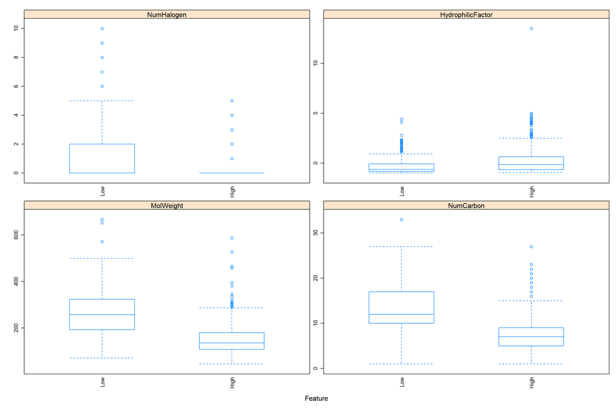

```r
##################################
# Formulating the box plots
##################################
featurePlot(x = EDA.Predictors.Numeric,
            y = EDA$Log_Solubility_Class,
            plot = "box",
            scales = list(x = list(relation="free", rot = 90),
                          y = list(relation="free")),
            adjust = 1.5,
            pch = "|")
```

## 1.5 Predictive Model Development and Dichotomization Thresholding

### 1.5.1 Logistic Regression Model Index and Probability Curve Estimation

[Logistic Regression](http://dx.doi.org/10.2139/ssrn.360300) models the relationship between the probability of an event (among two outcome levels) by having the log-odds of the event be a linear combination of a set of predictors weighted by their respective parameter estimates. The parameters are estimated via maximum likelihood estimation by testing different values through multiple iterations to optimize for the best fit of log odds. All of these iterations produce the log likelihood function, and logistic regression seeks to maximize this function to find the best parameter estimates. Given the optimal parameters, the conditional probabilities for each observation can be calculated, logged, and summed together to yield a predicted probability.  
**[A]** The logistic regression model from both the **stats** and **caret** packages was implemented. The Log_Solubility_Class response was regressed against the MolWeight, NumCarbon, NumHalogen and HydrophilicFactor predictors.  
**[B]** The logistic curve was formulated by plotting the predicted probabilities against the classification index using the logit values.  
**[C]** Discrimination power of the model was quantified using the area of the receiver operating characteristic curve, formulated for both the predicted probabilities and classification index. However, the subsequent exercise on exploring dichotomization thresholds was only applied on the predicted probabilities.  
**[D]** The performance of the model is summarized as follows:  
**[D.1]** Final model configuration is fixed due to the absence of a hyperparameter  
**[D.2]** Apparent ROC Curve AUC = 0.91432  
**[D.3]** Cross-Validated ROC Curve AUC = 0.91229  
**[E]** The model allows for ranking of predictors in terms of variable importance. The top-performing predictors in the model are as follows:  
**[E.1]** HydrophilicFactor variable (numeric)  
**[E.2]** NumCarbon variable (numeric)  
**[E.3]** NumHalogen variable (numeric)

**Code Chunk | Output**

```r
##################################
# Creating a local object
# for the train set
##################################
PMA_PreModelling_Train_LR <- PMA_PreModelling_Train

##################################
# Formulating the Logistic Regression model
##################################
LR_Model <-  PMA_PreModelling_Train_LR %>%
  mutate(Log_Solubility_Class = as.factor(Log_Solubility_Class)) %>%
  glm(formula = Log_Solubility_Class ~ MolWeight +
        NumCarbon +
        NumHalogen +
        HydrophilicFactor,
      family = binomial)

##################################
# Consolidating the model results
##################################
summary(LR_Model)
```

```
##
## Call:
## glm(formula = Log_Solubility_Class ~ MolWeight + NumCarbon +
##     NumHalogen + HydrophilicFactor, family = binomial, data = .)
##
## Deviance Residuals:
##     Min       1Q   Median       3Q      Max
## -2.2886  -0.4547   0.1621   0.5964   3.4332
##
## Coefficients:
##                    Estimate Std. Error z value Pr(>|z|)
## (Intercept)        5.432065   0.361092  15.043  < 2e-16 ***
## MolWeight         -0.007881   0.002473  -3.187  0.00144 **
## NumCarbon         -0.319809   0.044961  -7.113 1.14e-12 ***
## NumHalogen        -0.767695   0.130296  -5.892 3.82e-09 ***
## HydrophilicFactor  1.092854   0.145385   7.517 5.61e-14 ***
## ---
## Signif. codes:  0 '***' 0.001 '**' 0.01 '*' 0.05 '.' 0.1 ' ' 1
##
## (Dispersion parameter for binomial family taken to be 1)
##
##     Null deviance: 1308.45  on 950  degrees of freedom
## Residual deviance:  709.09  on 946  degrees of freedom
## AIC: 719.09
##
## Number of Fisher Scoring iterations: 6
```

```r
##################################
# Computing the model predictions
##################################
LR_Model_Predictions <- augment(LR_Model,
                               type.predict = 'response',
                               newdata = PMA_PreModelling_Train_LR,
                               se_fit = TRUE) %>%
    mutate(lower = .fitted - 1.96*.se.fit,
           upper = .fitted + 1.96*.se.fit) %>%
    mutate_if(is.numeric, ~ round(.,5))

LR_Model_Predictions <- as.data.frame(LR_Model_Predictions)

LR_Model_Predictions$LR_Prob <- LR_Model_Predictions$.fitted
LR_Model_Predictions$LR_SE   <- LR_Model_Predictions$.se.fit
LR_Model_Predictions$LR_UCL  <- LR_Model_Predictions$lower
LR_Model_Predictions$LR_LCL  <- LR_Model_Predictions$upper

##################################
# Creating a classification index
# based from the model predictions
##################################
LR_Model_Predictions$LR_LP   <- log(LR_Model_Predictions$LR_Prob/(1-LR_Model_Predictions$LR_Prob))

(LR_Model_Predictions <- LR_Model_Predictions[,!names(LR_Model_Predictions) %in%
                                                c(".fitted",
                                                  ".se.fit",
                                                  "lower",
                                                  "upper")])
```

```
##     .rownames MolWeight NumCarbon NumHalogen HydrophilicFactor
## 1         661    208.28        14          0            -0.856
## 2         662    365.54        21          0            -0.370
## 3         663    206.31        13          0            -0.330
## 4         665    136.26        10          0            -0.960
## 5         668    229.75         9          1            -0.069
## 6         669    270.25        10          2            -0.651
## 7         670    343.23        17          2            -0.729
## 8         671    200.36        12          0            -0.835
## 9         672    376.51        22          1             0.194
## 10        673    232.36        14          0             0.353
## 11        674    230.28        14          0            -0.807
## 12        676    288.47        19          0            -0.432
## 13        677    156.24        12          0            -0.969
## 14        678    162.62        10          1            -0.877
```

[output cut: 1889 more lines]

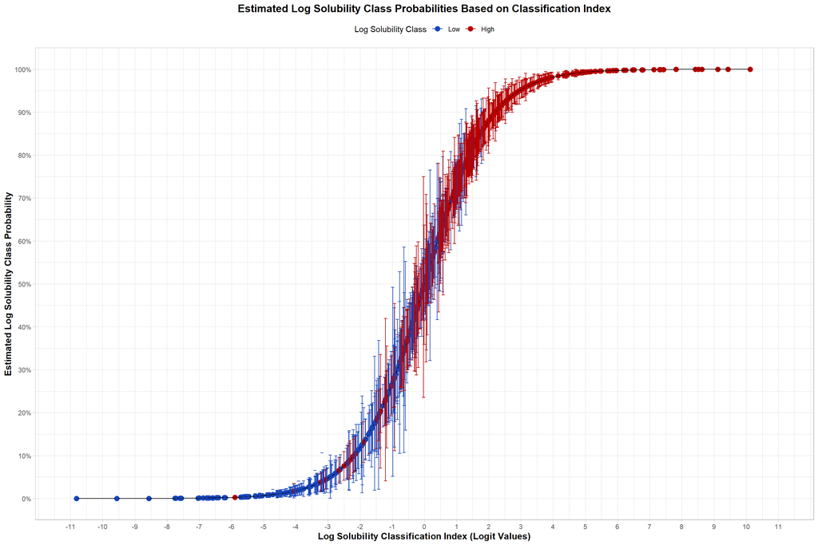

```r
##################################
# Winsorizing confidence interval values
# beyond the 0 and 1 range
##################################
LR_Model_Predictions$LR_LCL <- ifelse(LR_Model_Predictions$LR_LCL<0.000,0.001,
                                      LR_Model_Predictions$LR_LCL)
LR_Model_Predictions$LR_UCL <- ifelse(LR_Model_Predictions$LR_UCL>0.995,0.999,
                                      LR_Model_Predictions$LR_UCL)

##################################
# Formulating the probability curve
# using the model predictions and
# the classification index
##################################
LR_Model_Predictions %>%
  ggplot(aes(x = LR_LP ,
             y = LR_Prob,
             color = Log_Solubility_Class)) +
  scale_colour_manual(values=c("#1846BA","#B80000")) +
  geom_point(size=3) +
  geom_line(color="black") +
  geom_errorbar(aes(ymin = LR_LCL,
                    ymax = LR_UCL),
                width = .1) +
  xlab("Log Solubility Classification Index (Logit Values)") +
  ylab("Estimated Log Solubility Class Probability") +
  labs(color = "Log Solubility Class") +
  scale_x_continuous( limits=c(-11,11), breaks=seq(-11,11,by=1)) +
  scale_y_continuous( limits=c(0,1), breaks=seq(0,1,by=0.1),labels = scales::percent) +
  ggtitle("Estimated Log Solubility Class Probabilities Based on Classification Index") +
  theme_light() +
  theme(plot.title = element_text(color="black", size=14, face="bold", hjust=0.50),
        axis.title.x = element_text(color="black", size=12, face="bold"),
        axis.title.y = element_text(color="black", size=12, face="bold"),
        legend.position="top")
```

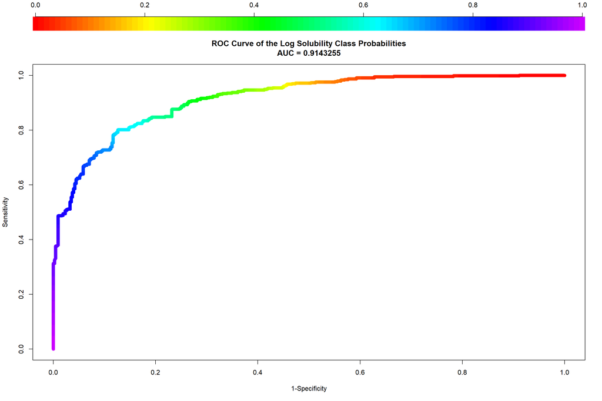

```r
##################################
# Formulating the corresponding
# receiver operating characteristic (ROC) curve
# using the model predictions
##################################
LR_Prob_Low  <- LR_Model_Predictions[LR_Model_Predictions$Log_Solubility_Class=="Low",
                                    c("LR_Prob")]
LR_Prob_High <- LR_Model_Predictions[LR_Model_Predictions$Log_Solubility_Class=="High",
                                    c("LR_Prob")]
LR_Model_Prob_ROC <- roc.curve(scores.class1 = LR_Prob_Low,
                               scores.class0 = LR_Prob_High,
                                curve = TRUE)

plot(LR_Model_Prob_ROC,
     xlab="1-Specificity",
     ylab="Sensitivity",
     main="ROC Curve of the Log Solubility Class Probabilities",
     color=TRUE,
     lwd=8,
     legend=3)
```

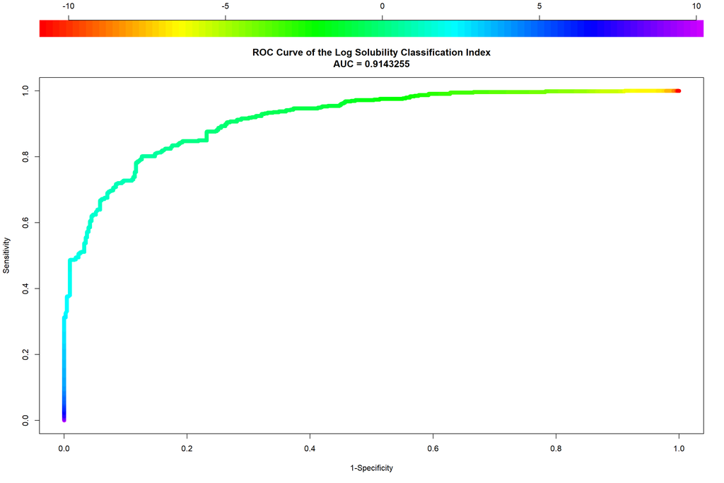

```r
##################################
# Formulating the corresponding
# receiver operating characteristic (ROC) curve
# using the classification index
##################################
LR_LP_Low  <- LR_Model_Predictions[LR_Model_Predictions$Log_Solubility_Class=="Low",
                                    c("LR_LP")]
LR_LP_High <- LR_Model_Predictions[LR_Model_Predictions$Log_Solubility_Class=="High",
                                    c("LR_LP")]
LR_Model_LP_ROC <- roc.curve(scores.class1 = LR_LP_Low,
                             scores.class0 = LR_LP_High,
                             curve = TRUE)

plot(LR_Model_LP_ROC,
     xlab="1-Specificity",
     ylab="Sensitivity",
     main="ROC Curve of the Log Solubility Classification Index",
     color=TRUE,
     lwd=8,
     legend=3)
```

```r
##################################
# Conducting internal model validation
##################################
##################################
# Creating consistent fold assignments
# for the 10-Fold Cross Validation process
##################################
set.seed(12345678)
KFold_Indices <- createFolds(PMA_PreModelling_Train_LR$Log_Solubility_Class,
                             k = 10,
                             returnTrain=TRUE)
KFold_Control <- trainControl(method="cv",
                              index=KFold_Indices,
                              summaryFunction = twoClassSummary,
                              classProbs = TRUE)

##################################
# Setting the conditions
# for hyperparameter tuning
##################################
# No hyperparameter tuning process conducted
# hyperparameter=intercept fixed to TRUE

##################################
# Running the logistic regression model
# by setting the caret method to 'glm'
##################################
set.seed(12345678)
LR_Tune <- train(x = PMA_PreModelling_Train_LR[,!names(PMA_PreModelling_Train_LR) %in% c("Log_Solubility_Class")],
                 y = PMA_PreModelling_Train_LR$Log_Solubility_Class,
                 method = "glm",
                 metric = "ROC",
                 trControl = KFold_Control)

##################################
# Reporting the cross-validation results
# for the train set
##################################
LR_Tune
```

```
## Generalized Linear Model
##
## 951 samples
##   4 predictor
##   2 classes: 'Low', 'High'
##
## No pre-processing
## Resampling: Cross-Validated (10 fold)
## Summary of sample sizes: 857, 855, 857, 855, 856, 856, ...
## Resampling results:
##
##   ROC        Sens       Spec
##   0.9122974  0.7539313  0.8722061
```

```r
LR_Tune$finalModel
```

```
##
## Call:  NULL
##
## Coefficients:
##       (Intercept)          MolWeight          NumCarbon         NumHalogen
##          5.432065          -0.007881          -0.319809          -0.767695
## HydrophilicFactor
##          1.092854
##
## Degrees of Freedom: 950 Total (i.e. Null);  946 Residual
## Null Deviance:       1308
## Residual Deviance: 709.1     AIC: 719.1
```

```r
LR_Tune$results
```

```
##   parameter       ROC      Sens      Spec     ROCSD     SensSD     SpecSD
## 1      none 0.9122974 0.7539313 0.8722061 0.0302158 0.05915241 0.05739572
```

```r
(LR_Train_ROCCurveAUC <- LR_Tune$results$ROC)
```

```
## [1] 0.9122974
```

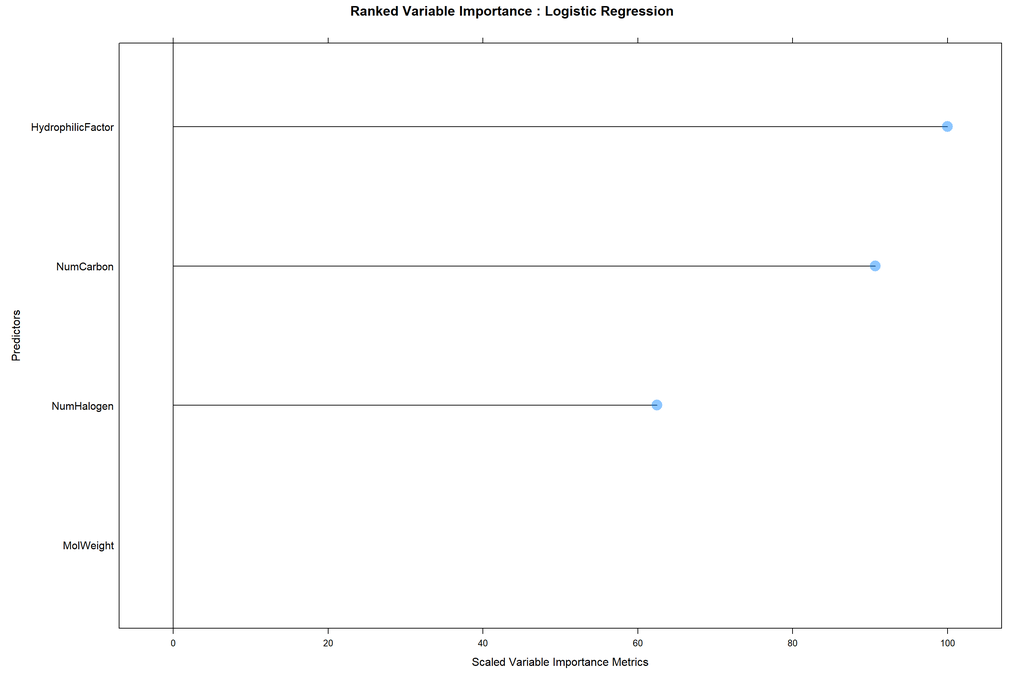

```r
##################################
# Identifying and plotting the
# best model predictors
##################################
LR_VarImp <- varImp(LR_Tune, scale = TRUE)
plot(LR_VarImp,
     top=4,
     scales=list(y=list(cex = .95)),
     main="Ranked Variable Importance : Logistic Regression",
     xlab="Scaled Variable Importance Metrics",
     ylab="Predictors",
     cex=2,
     origin=0,
     alpha=0.45)
```

### 1.5.2 Threshold Criterion Using Minimum Sensitivity (TC_MinValueSe)

[Minimum Sensitivity](https://onlinelibrary.wiley.com/doi/10.1002/sim.4780081110) is a threshold criterion based on setting a minimum value for Sensitivity and maximizing Specificity, subject to this condition. Hence, in a case where there is more than one cutpoint fulfilling this condition, those which yield maximum Specificity are chosen. If several cutpoints still remain, those yielding the greatest Sensitivity are chosen.  
**[A]** The MinValueSe threshold criterion from the **OptimalCutpoints** package was used which applies a minimum value set for sensitivity.  
**[B]** The threshold criterion requires to set 1 parameter:  
**[B.1]** valueSe = minimum sensitivity value set at 0.90  
**[C]** The determined optimal dichotomization threshold and corresponding classification metrics are summarized as follows:  
**[C.1]** Log Solubility Class Probability Threshold = 0.44773  
**[C.2]** Apparent Sensitivity = 0.90458  
**[C.3]** Apparent Specificity = 0.73536

**Code Chunk | Output**

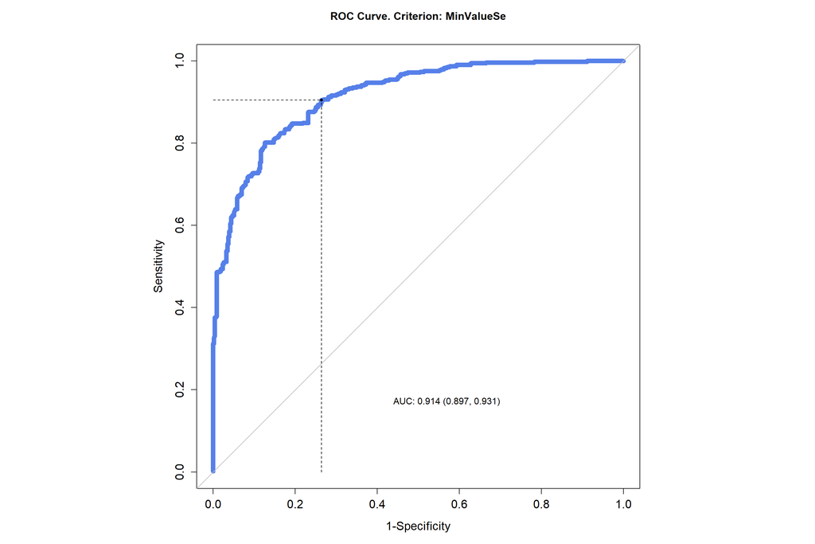

```r
######################################
# Creating a function to gather the
# classification metrics applying the
# threshold criterion using a
# minimum value set for sensitivity
######################################
ClassificationMetrics.Class0.LO.MINVALUESE <- function(SourceData,Response,Predictor){
  ThresholdCriterion <- optimal.cutpoints(X = Predictor,
                                         status = Response,
                                         tag.healthy = "Low",
                                         methods = c("MinValueSe"),
                                         data = SourceData,
                                         pop.prev = NULL,
                                         control = control.cutpoints(valueSe=0.90),
                                         ci.fit = FALSE,
                                         direction = c("<"))

  summary(ThresholdCriterion)
  (OptimalThreshold <- ThresholdCriterion$MinValueSe$Global$optimal.cutoff$cutoff[1])
  (ThresholdSensitivity <- ThresholdCriterion$MinValueSe$Global$optimal.cutoff$Se[,1][1])
  (ThresholdSpecificity <- ThresholdCriterion$MinValueSe$Global$optimal.cutoff$Sp[,1][1])
  (ThresholdROCAUC <- ThresholdCriterion$MinValueSe$Global$measures.acc$AUC[1])
  plot.optimal.cutpoints(ThresholdCriterion,
                         col=c("#5680E9"),
                         legend=FALSE,
                         which=1,
                         xlim=c(0,1),
                         ylim=c(0,1),
                         lwd=8)
  ClassificationMetricsList <-list(OptimalThreshold,
                                   ThresholdSensitivity,
                                   ThresholdSpecificity,
                                   ThresholdROCAUC)
  return(ClassificationMetricsList)
}

ClassificationMetrics.Class0.HI.MINVALUESE <- function(SourceData,Response,Predictor){
  ThresholdCriterion <- optimal.cutpoints(X = Predictor,
                                         status = Response,
                                         tag.healthy = "Low",
                                         methods = c("MinValueSe"),
                                         data = SourceData,
                                         pop.prev = NULL,
                                         control = control.cutpoints(valueSe=0.90),
                                         ci.fit = FALSE,
                                         direction = c(">"))

  summary(ThresholdCriterion)
  (OptimalThreshold <- ThresholdCriterion$MinValueSe$Global$optimal.cutoff$cutoff[1])
  (ThresholdSensitivity <- ThresholdCriterion$MinValueSe$Global$optimal.cutoff$Se[,1][1])
  (ThresholdSpecificity <- ThresholdCriterion$MinValueSe$Global$optimal.cutoff$Sp[,1][1])
  (ThresholdROCAUC <- ThresholdCriterion$MinValueSe$Global$measures.acc$AUC[1])
  plot.optimal.cutpoints(ThresholdCriterion,
                         col=c("#5680E9"),
                         legend=FALSE,
                         which=1,
                         xlim=c(0,1),
                         ylim=c(0,1),
                         lwd=8)
  ClassificationMetricsList <-list(OptimalThreshold,
                                   ThresholdSensitivity,
                                   ThresholdSpecificity,
                                   ThresholdROCAUC)
  return(ClassificationMetricsList)
}

######################################
# Gather the classification metrics
######################################
OPTTH.List <- list()
THSEN.List <- list()
THSPE.List <- list()
THAUC.List <- list()
PREDI.List <- list()

for (i in 7:7) {
  Response.i  <- colnames(LR_Model_Predictions)[6]
  Predictor.i <- colnames(LR_Model_Predictions)[i]

  ClassificationMetrics.i <- ClassificationMetrics.Class0.LO.MINVALUESE(LR_Model_Predictions,
                                                                    Response.i,
                                                                    Predictor.i)
  OPTTH.i <- as.numeric(as.character(sprintf(ClassificationMetrics.i[1],fmt='%#.5f')))
  THSEN.i <- as.numeric(as.character(sprintf(ClassificationMetrics.i[2],fmt='%#.5f')))
  THSPE.i <- as.numeric(as.character(sprintf(ClassificationMetrics.i[3],fmt='%#.5f')))
  THAUC.i <- as.numeric(as.character(sprintf(ClassificationMetrics.i[4],fmt='%#.5f')))

  PREDI.List <- append(PREDI.List,Predictor.i)
  OPTTH.List <- append(OPTTH.List,OPTTH.i)
  THSEN.List <- append(THSEN.List,THSEN.i)
  THSPE.List <- append(THSPE.List,THSPE.i)
  THAUC.List <- append(THAUC.List,THAUC.i)
}
```

```r
ClassificationMetrics.SUMMARY <- cbind(PREDI.List,
                                       THAUC.List,
                                       OPTTH.List,
                                       THSEN.List,
                                       THSPE.List
)

colnames(ClassificationMetrics.SUMMARY) <- c("Predictor",
                                             "ROCAUC",
                                             "OptimalThreshold.MINVALUESE",
                                             "ApparentSensitivity",
                                             "ApparentSpecificity")

MINVALUESE.SUMMARY <- as.data.frame(ClassificationMetrics.SUMMARY)
MINVALUESE.SUMMARY$ROCAUC <- as.numeric(as.character(MINVALUESE.SUMMARY$ROCAUC))
MINVALUESE.SUMMARY$ApparentSensitivity <- as.numeric(as.character(MINVALUESE.SUMMARY$ApparentSensitivity))
MINVALUESE.SUMMARY$ApparentSpecificity <- as.numeric(as.character(MINVALUESE.SUMMARY$ApparentSpecificity))

(MINVALUESE.Threshold <- MINVALUESE.SUMMARY$OptimalThreshold.MINVALUESE)
```

```
## $OptimalThreshold.MINVALUESE
## [1] 0.44773
```

```r
(MINVALUESE.Sensitivity <- MINVALUESE.SUMMARY$ApparentSensitivity)
```

```
## [1] 0.90458
```

```r
(MINVALUESE.Specificity <- MINVALUESE.SUMMARY$ApparentSpecificity)
```

```
## [1] 0.73536
```

### 1.5.3 Threshold Criterion Using Minimum Specificity (TC_MinValueSp)

[Minimum Specificity](https://onlinelibrary.wiley.com/doi/10.1002/sim.4780081110) is a threshold criterion based on setting a minimum value for Specificity and maximizing Sensitivity, subject to this condition. Hence, in a case where there is more than one cutpoint fulfilling this condition, those which yield maximum Sensitivity are chosen. If several cutpoints still remain, those yielding the greatest Specificity are chosen.  
**[A]** The MinValueSp threshold criterion from the **OptimalCutpoints** package was used which applies a minimum value set for specificity.  
**[B]** The threshold criterion requires to set 1 parameter:  
**[B.1]** valueSp = minimum specificity value set at 0.90  
**[C]** The determined optimal dichotomization threshold and corresponding classification metrics are summarized as follows:  
**[C.1]** Log Solubility Class Probability Threshold = 0.72336  
**[C.2]** Apparent Sensitivity = 0.72710  
**[C.3]** Apparent Specificity = 0.90398

**Code Chunk | Output**

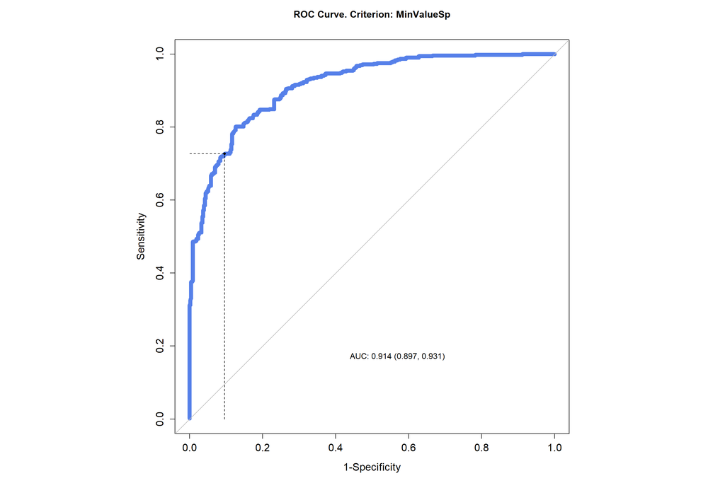

```r
######################################
# Creating a function to gather the
# classification metrics applying the
# threshold criterion using a
# minimum value set for specificity
######################################
ClassificationMetrics.Class0.LO.MINVALUESP <- function(SourceData,Response,Predictor){
  ThresholdCriterion <- optimal.cutpoints(X = Predictor,
                                         status = Response,
                                         tag.healthy = "Low",
                                         methods = c("MinValueSp"),
                                         data = SourceData,
                                         pop.prev = NULL,
                                         control = control.cutpoints(valueSp=0.90),
                                         ci.fit = FALSE,
                                         direction = c("<"))

  summary(ThresholdCriterion)
  (OptimalThreshold <- ThresholdCriterion$MinValueSp$Global$optimal.cutoff$cutoff[1])
  (ThresholdSensitivity <- ThresholdCriterion$MinValueSp$Global$optimal.cutoff$Se[,1][1])
  (ThresholdSpecificity <- ThresholdCriterion$MinValueSp$Global$optimal.cutoff$Sp[,1][1])
  (ThresholdROCAUC <- ThresholdCriterion$MinValueSp$Global$measures.acc$AUC[1])
  plot.optimal.cutpoints(ThresholdCriterion,
                         col=c("#5680E9"),
                         legend=FALSE,
                         which=1,
                         xlim=c(0,1),
                         ylim=c(0,1),
                         lwd=8)
  ClassificationMetricsList <-list(OptimalThreshold,
                                   ThresholdSensitivity,
                                   ThresholdSpecificity,
                                   ThresholdROCAUC)
  return(ClassificationMetricsList)
}

ClassificationMetrics.Class0.HI.MINVALUESP <- function(SourceData,Response,Predictor){
  ThresholdCriterion <- optimal.cutpoints(X = Predictor,
                                         status = Response,
                                         tag.healthy = "Low",
                                         methods = c("MinValueSp"),
                                         data = SourceData,
                                         pop.prev = NULL,
                                         control = control.cutpoints(valueSp=0.90),
                                         ci.fit = FALSE,
                                         direction = c(">"))

  summary(ThresholdCriterion)
  (OptimalThreshold <- ThresholdCriterion$MinValueSp$Global$optimal.cutoff$cutoff[1])
  (ThresholdSensitivity <- ThresholdCriterion$MinValueSp$Global$optimal.cutoff$Se[,1][1])
  (ThresholdSpecificity <- ThresholdCriterion$MinValueSp$Global$optimal.cutoff$Sp[,1][1])
  (ThresholdROCAUC <- ThresholdCriterion$MinValueSp$Global$measures.acc$AUC[1])
  plot.optimal.cutpoints(ThresholdCriterion,
                         col=c("#5680E9"),
                         legend=FALSE,
                         which=1,
                         xlim=c(0,1),
                         ylim=c(0,1),
                         lwd=8)
  ClassificationMetricsList <-list(OptimalThreshold,
                                   ThresholdSensitivity,
                                   ThresholdSpecificity,
                                   ThresholdROCAUC)
  return(ClassificationMetricsList)
}

######################################
# Gather the classification metrics
######################################
OPTTH.List <- list()
THSEN.List <- list()
THSPE.List <- list()
THAUC.List <- list()
PREDI.List <- list()

for (i in 7:7) {
  Response.i  <- colnames(LR_Model_Predictions)[6]
  Predictor.i <- colnames(LR_Model_Predictions)[i]

  ClassificationMetrics.i <- ClassificationMetrics.Class0.LO.MINVALUESP(LR_Model_Predictions,
                                                                    Response.i,
                                                                    Predictor.i)
  OPTTH.i <- as.numeric(as.character(sprintf(ClassificationMetrics.i[1],fmt='%#.5f')))
  THSEN.i <- as.numeric(as.character(sprintf(ClassificationMetrics.i[2],fmt='%#.5f')))
  THSPE.i <- as.numeric(as.character(sprintf(ClassificationMetrics.i[3],fmt='%#.5f')))
  THAUC.i <- as.numeric(as.character(sprintf(ClassificationMetrics.i[4],fmt='%#.5f')))

  PREDI.List <- append(PREDI.List,Predictor.i)
  OPTTH.List <- append(OPTTH.List,OPTTH.i)
  THSEN.List <- append(THSEN.List,THSEN.i)
  THSPE.List <- append(THSPE.List,THSPE.i)
  THAUC.List <- append(THAUC.List,THAUC.i)
}
```

```r
ClassificationMetrics.SUMMARY <- cbind(PREDI.List,
                                       THAUC.List,
                                       OPTTH.List,
                                       THSEN.List,
                                       THSPE.List
)

colnames(ClassificationMetrics.SUMMARY) <- c("Predictor",
                                             "ROCAUC",
                                             "OptimalThreshold.MINVALUESP",
                                             "ApparentSensitivity",
                                             "ApparentSpecificity")

MINVALUESP.SUMMARY <- as.data.frame(ClassificationMetrics.SUMMARY)
MINVALUESP.SUMMARY$ROCAUC <- as.numeric(as.character(MINVALUESP.SUMMARY$ROCAUC))
MINVALUESP.SUMMARY$ApparentSensitivity <- as.numeric(as.character(MINVALUESP.SUMMARY$ApparentSensitivity))
MINVALUESP.SUMMARY$ApparentSpecificity <- as.numeric(as.character(MINVALUESP.SUMMARY$ApparentSpecificity))

(MINVALUESP.Threshold <- MINVALUESP.SUMMARY$OptimalThreshold.MINVALUESP)
```

```
## $OptimalThreshold.MINVALUESP
## [1] 0.72336
```

```r
(MINVALUESP.Sensitivity <- MINVALUESP.SUMMARY$ApparentSensitivity)
```

```
## [1] 0.7271
```

```r
(MINVALUESP.Specificity <- MINVALUESP.SUMMARY$ApparentSpecificity)
```

```
## [1] 0.90398
```

### 1.5.4 Threshold Criterion Using Maximum Product of Specificity and Sensitivity (TC_MaxProdSpSe)

[Maximum Product of Specificity and Sensitivity](https://academic.oup.com/ibdjournal/article/14/12/1660/4654949) is a threshold criterion based on the optimally highest product of Specificity and Sensitivity, which is the same as the method based on maximization of the Accuracy Area.  
**[A]** The MaxProdSpSe threshold criterion from the **OptimalCutpoints** package was used which maximizes the product of specificity and sensitivity or accuracy area.  
**[B]** The threshold criterion does not require to set any parameter.  
**[C]** The determined optimal dichotomization threshold and corresponding classification metrics are summarized as follows:  
**[C.1]** Log Solubility Class Probability Threshold = 0.64163  
**[C.2]** Apparent Sensitivity = 0.80153  
**[C.3]** Apparent Specificity = 0.87354

**Code Chunk | Output**

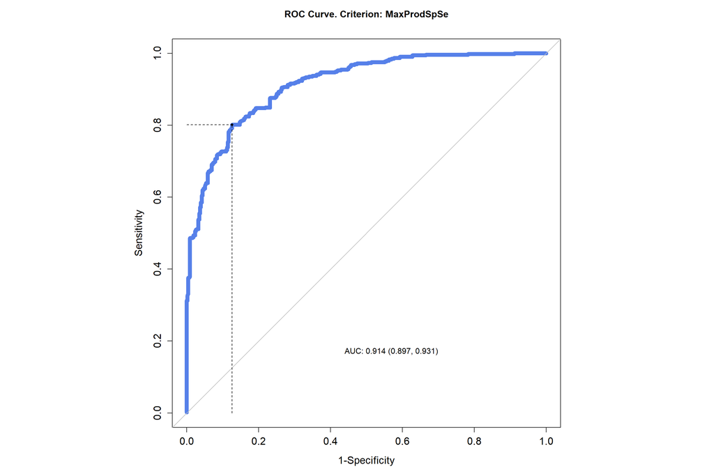

```r
######################################
# Creating a function to gather the
# classification metrics applying the
# threshold criterion which maximizes the
# product of specificity and sensitivity
# or accuracy area
######################################
ClassificationMetrics.Class0.LO.MAXPRODSPSE <- function(SourceData,Response,Predictor){
  ThresholdCriterion <- optimal.cutpoints(X = Predictor,
                                         status = Response,
                                         tag.healthy = "Low",
                                         methods = c("MaxProdSpSe"),
                                         data = SourceData,
                                         pop.prev = NULL,
                                         ci.fit = FALSE,
                                         direction = c("<"))

  summary(ThresholdCriterion)
  (OptimalThreshold <- ThresholdCriterion$MaxProdSpSe$Global$optimal.cutoff$cutoff[1])
  (ThresholdSensitivity <- ThresholdCriterion$MaxProdSpSe$Global$optimal.cutoff$Se[,1][1])
  (ThresholdSpecificity <- ThresholdCriterion$MaxProdSpSe$Global$optimal.cutoff$Sp[,1][1])
  (ThresholdROCAUC <- ThresholdCriterion$MaxProdSpSe$Global$measures.acc$AUC[1])
  plot.optimal.cutpoints(ThresholdCriterion,
                         col=c("#5680E9"),
                         legend=FALSE,
                         which=1,
                         xlim=c(0,1),
                         ylim=c(0,1),
                         lwd=8)
  ClassificationMetricsList <-list(OptimalThreshold,
                                   ThresholdSensitivity,
                                   ThresholdSpecificity,
                                   ThresholdROCAUC)
  return(ClassificationMetricsList)
}

ClassificationMetrics.Class0.HI.MAXPRODSPSE <- function(SourceData,Response,Predictor){
  ThresholdCriterion <- optimal.cutpoints(X = Predictor,
                                         status = Response,
                                         tag.healthy = "Low",
                                         methods = c("MaxProdSpSe"),
                                         data = SourceData,
                                         pop.prev = NULL,
                                         ci.fit = FALSE,
                                         direction = c(">"))

  summary(ThresholdCriterion)
  (OptimalThreshold <- ThresholdCriterion$MaxProdSpSe$Global$optimal.cutoff$cutoff[1])
  (ThresholdSensitivity <- ThresholdCriterion$MaxProdSpSe$Global$optimal.cutoff$Se[,1][1])
  (ThresholdSpecificity <- ThresholdCriterion$MaxProdSpSe$Global$optimal.cutoff$Sp[,1][1])
  (ThresholdROCAUC <- ThresholdCriterion$MaxProdSpSe$Global$measures.acc$AUC[1])
  plot.optimal.cutpoints(ThresholdCriterion,
                         col=c("#5680E9"),
                         legend=FALSE,
                         which=1,
                         xlim=c(0,1),
                         ylim=c(0,1),
                         lwd=8)
  ClassificationMetricsList <-list(OptimalThreshold,
                                   ThresholdSensitivity,
                                   ThresholdSpecificity,
                                   ThresholdROCAUC)
  return(ClassificationMetricsList)
}

######################################
# Gather the classification metrics
######################################
OPTTH.List <- list()
THSEN.List <- list()
THSPE.List <- list()
THAUC.List <- list()
PREDI.List <- list()

for (i in 7:7) {
  Response.i  <- colnames(LR_Model_Predictions)[6]
  Predictor.i <- colnames(LR_Model_Predictions)[i]

  ClassificationMetrics.i <- ClassificationMetrics.Class0.LO.MAXPRODSPSE(LR_Model_Predictions,
                                                                    Response.i,
                                                                    Predictor.i)
  OPTTH.i <- as.numeric(as.character(sprintf(ClassificationMetrics.i[1],fmt='%#.5f')))
  THSEN.i <- as.numeric(as.character(sprintf(ClassificationMetrics.i[2],fmt='%#.5f')))
  THSPE.i <- as.numeric(as.character(sprintf(ClassificationMetrics.i[3],fmt='%#.5f')))
  THAUC.i <- as.numeric(as.character(sprintf(ClassificationMetrics.i[4],fmt='%#.5f')))

  PREDI.List <- append(PREDI.List,Predictor.i)
  OPTTH.List <- append(OPTTH.List,OPTTH.i)
  THSEN.List <- append(THSEN.List,THSEN.i)
  THSPE.List <- append(THSPE.List,THSPE.i)
  THAUC.List <- append(THAUC.List,THAUC.i)
}
```

```r
ClassificationMetrics.SUMMARY <- cbind(PREDI.List,
                                       THAUC.List,
                                       OPTTH.List,
                                       THSEN.List,
                                       THSPE.List
)

colnames(ClassificationMetrics.SUMMARY) <- c("Predictor",
                                             "ROCAUC",
                                             "OptimalThreshold.MAXPRODSPSE",
                                             "ApparentSensitivity",
                                             "ApparentSpecificity")

MAXPRODSPSE.SUMMARY <- as.data.frame(ClassificationMetrics.SUMMARY)
MAXPRODSPSE.SUMMARY$ROCAUC <- as.numeric(as.character(MAXPRODSPSE.SUMMARY$ROCAUC))
MAXPRODSPSE.SUMMARY$ApparentSensitivity <- as.numeric(as.character(MAXPRODSPSE.SUMMARY$ApparentSensitivity))
MAXPRODSPSE.SUMMARY$ApparentSpecificity <- as.numeric(as.character(MAXPRODSPSE.SUMMARY$ApparentSpecificity))

(MAXPRODSPSE.Threshold <- MAXPRODSPSE.SUMMARY$OptimalThreshold.MAXPRODSPSE)
```

```
## $OptimalThreshold.MAXPRODSPSE
## [1] 0.64163
```

```r
(MAXPRODSPSE.Sensitivity <- MAXPRODSPSE.SUMMARY$ApparentSensitivity)
```

```
## [1] 0.80153
```

```r
(MAXPRODSPSE.Specificity <- MAXPRODSPSE.SUMMARY$ApparentSpecificity)
```

```
## [1] 0.87354
```

### 1.5.5 Threshold Criterion Using ROC Curve Point Closest to Point (0,1) (TC_ROC01)

[ROC Curve Point Closest to Point (0,1)](https://www.sciencedirect.com/science/article/abs/pii/S0001299878800142?via%3Dihub) is a threshold criterion which refers to the upper leftmost corner of the unit square.  
**[A]** The ROC01 threshold criterion from the **OptimalCutpoints** package was used which minimizes the distance between the ROC plot and point (0,1).  
**[B]** The threshold criterion does not require to set any parameter.  
**[C]** The determined optimal dichotomization threshold and corresponding classification metrics are summarized as follows:  
**[C.1]** Log Solubility Class Probability Threshold = 0.64163  
**[C.2]** Apparent Sensitivity = 0.80153  
**[C.3]** Apparent Specificity = 0.87354

**Code Chunk | Output**

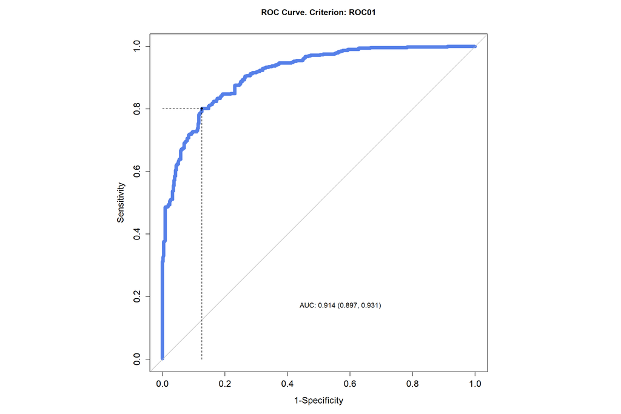

```r
######################################
# Creating a function to gather the
# classification metrics applying the
# threshold criterion which minimizes the
# distance between the ROC plot and point (0,1)
######################################
ClassificationMetrics.Class0.LO.ROC01 <- function(SourceData,Response,Predictor){
  ThresholdCriterion <- optimal.cutpoints(X = Predictor,
                                         status = Response,
                                         tag.healthy = "Low",
                                         methods = c("ROC01"),
                                         data = SourceData,
                                         pop.prev = NULL,
                                         ci.fit = FALSE,
                                         direction = c("<"))

  summary(ThresholdCriterion)
  (OptimalThreshold <- ThresholdCriterion$ROC01$Global$optimal.cutoff$cutoff[1])
  (ThresholdSensitivity <- ThresholdCriterion$ROC01$Global$optimal.cutoff$Se[,1][1])
  (ThresholdSpecificity <- ThresholdCriterion$ROC01$Global$optimal.cutoff$Sp[,1][1])
  (ThresholdROCAUC <- ThresholdCriterion$ROC01$Global$measures.acc$AUC[1])
  plot.optimal.cutpoints(ThresholdCriterion,
                         col=c("#5680E9"),
                         legend=FALSE,
                         which=1,
                         xlim=c(0,1),
                         ylim=c(0,1),
                         lwd=8)
  ClassificationMetricsList <-list(OptimalThreshold,
                                   ThresholdSensitivity,
                                   ThresholdSpecificity,
                                   ThresholdROCAUC)
  return(ClassificationMetricsList)
}

ClassificationMetrics.Class0.HI.ROC01 <- function(SourceData,Response,Predictor){
  ThresholdCriterion <- optimal.cutpoints(X = Predictor,
                                         status = Response,
                                         tag.healthy = "Low",
                                         methods = c("ROC01"),
                                         data = SourceData,
                                         pop.prev = NULL,
                                         ci.fit = FALSE,
                                         direction = c(">"))

  summary(ThresholdCriterion)
  (OptimalThreshold <- ThresholdCriterion$ROC01$Global$optimal.cutoff$cutoff[1])
  (ThresholdSensitivity <- ThresholdCriterion$ROC01$Global$optimal.cutoff$Se[,1][1])
  (ThresholdSpecificity <- ThresholdCriterion$ROC01$Global$optimal.cutoff$Sp[,1][1])
  (ThresholdROCAUC <- ThresholdCriterion$ROC01$Global$measures.acc$AUC[1])
  plot.optimal.cutpoints(ThresholdCriterion,
                         col=c("#5680E9"),
                         legend=FALSE,
                         which=1,
                         xlim=c(0,1),
                         ylim=c(0,1),
                         lwd=8)
  ClassificationMetricsList <-list(OptimalThreshold,
                                   ThresholdSensitivity,
                                   ThresholdSpecificity,
                                   ThresholdROCAUC)
  return(ClassificationMetricsList)
}

######################################
# Gather the classification metrics
######################################
OPTTH.List <- list()
THSEN.List <- list()
THSPE.List <- list()
THAUC.List <- list()
PREDI.List <- list()

for (i in 7:7) {
  Response.i  <- colnames(LR_Model_Predictions)[6]
  Predictor.i <- colnames(LR_Model_Predictions)[i]

  ClassificationMetrics.i <- ClassificationMetrics.Class0.LO.ROC01(LR_Model_Predictions,
                                                                    Response.i,
                                                                    Predictor.i)
  OPTTH.i <- as.numeric(as.character(sprintf(ClassificationMetrics.i[1],fmt='%#.5f')))
  THSEN.i <- as.numeric(as.character(sprintf(ClassificationMetrics.i[2],fmt='%#.5f')))
  THSPE.i <- as.numeric(as.character(sprintf(ClassificationMetrics.i[3],fmt='%#.5f')))
  THAUC.i <- as.numeric(as.character(sprintf(ClassificationMetrics.i[4],fmt='%#.5f')))

  PREDI.List <- append(PREDI.List,Predictor.i)
  OPTTH.List <- append(OPTTH.List,OPTTH.i)
  THSEN.List <- append(THSEN.List,THSEN.i)
  THSPE.List <- append(THSPE.List,THSPE.i)
  THAUC.List <- append(THAUC.List,THAUC.i)
}
```

```r
ClassificationMetrics.SUMMARY <- cbind(PREDI.List,
                                       THAUC.List,
                                       OPTTH.List,
                                       THSEN.List,
                                       THSPE.List
)

colnames(ClassificationMetrics.SUMMARY) <- c("Predictor",
                                             "ROCAUC",
                                             "OptimalThreshold.ROC01",
                                             "ApparentSensitivity",
                                             "ApparentSpecificity")

ROC01.SUMMARY <- as.data.frame(ClassificationMetrics.SUMMARY)
ROC01.SUMMARY$ROCAUC <- as.numeric(as.character(ROC01.SUMMARY$ROCAUC))
ROC01.SUMMARY$ApparentSensitivity <- as.numeric(as.character(ROC01.SUMMARY$ApparentSensitivity))
ROC01.SUMMARY$ApparentSpecificity <- as.numeric(as.character(ROC01.SUMMARY$ApparentSpecificity))

(ROC01.Threshold <- ROC01.SUMMARY$OptimalThreshold.ROC01)
```

```
## $OptimalThreshold.ROC01
## [1] 0.64163
```

```r
(ROC01.Sensitivity <- ROC01.SUMMARY$ApparentSensitivity)
```

```
## [1] 0.80153
```

```r
(ROC01.Specificity <- ROC01.SUMMARY$ApparentSpecificity)
```

```
## [1] 0.87354
```

### 1.5.6 Threshold Criterion Using Sensitivity Equals Specificity (TC_SpEqualSe)

[Sensitivity Equals Specificity](https://www.sciencedirect.com/science/article/abs/pii/002217599500078O) is a threshold criterion based on the equality of Sensitivity and Specificity. Since Specificity may not be exactly equal to Sensitivity, the absolute value of the difference between them is minimized.  
**[A]** The SpEqualSe threshold criterion from the **OptimalCutpoints** package was applies the ROC curve point where specificity approximately equals sensitivity.  
**[B]** The threshold criterion does not require to set any parameter.  
**[C]** The determined optimal dichotomization threshold and corresponding classification metrics are summarized as follows:  
**[C.1]** Log Solubility Class Probability Threshold = 0.61205  
**[C.2]** Apparent Sensitivity = 0.82634  
**[C.3]** Apparent Specificity = 0.82670

**Code Chunk | Output**

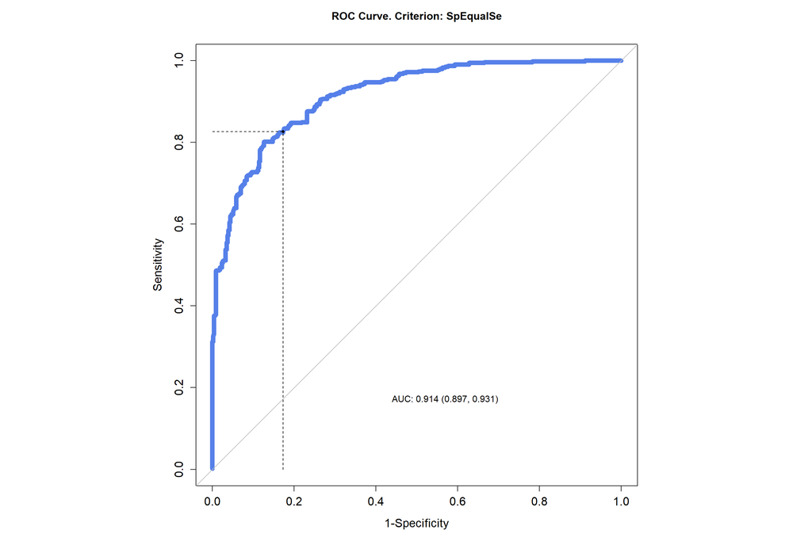

```r
######################################
# Creating a function to gather the
# classification metrics applying the
# threshold criterion using the ROC curve point where
# specificity approximately equals sensitivity
######################################
ClassificationMetrics.Class0.LO.SPEQUALSE <- function(SourceData,Response,Predictor){
  ThresholdCriterion <- optimal.cutpoints(X = Predictor,
                                         status = Response,
                                         tag.healthy = "Low",
                                         methods = c("SpEqualSe"),
                                         data = SourceData,
                                         pop.prev = NULL,
                                         ci.fit = FALSE,
                                         direction = c("<"))

  summary(ThresholdCriterion)
  (OptimalThreshold <- ThresholdCriterion$SpEqualSe$Global$optimal.cutoff$cutoff[1])
  (ThresholdSensitivity <- ThresholdCriterion$SpEqualSe$Global$optimal.cutoff$Se[,1][1])
  (ThresholdSpecificity <- ThresholdCriterion$SpEqualSe$Global$optimal.cutoff$Sp[,1][1])
  (ThresholdROCAUC <- ThresholdCriterion$SpEqualSe$Global$measures.acc$AUC[1])
  plot.optimal.cutpoints(ThresholdCriterion,
                         col=c("#5680E9"),
                         legend=FALSE,
                         which=1,
                         xlim=c(0,1),
                         ylim=c(0,1),
                         lwd=8)
  ClassificationMetricsList <-list(OptimalThreshold,
                                   ThresholdSensitivity,
                                   ThresholdSpecificity,
                                   ThresholdROCAUC)
  return(ClassificationMetricsList)
}

ClassificationMetrics.Class0.HI.SPEQUALSE <- function(SourceData,Response,Predictor){
  ThresholdCriterion <- optimal.cutpoints(X = Predictor,
                                         status = Response,
                                         tag.healthy = "Low",
                                         methods = c("SpEqualSe"),
                                         data = SourceData,
                                         pop.prev = NULL,
                                         ci.fit = FALSE,
                                         direction = c(">"))

  summary(ThresholdCriterion)
  (OptimalThreshold <- ThresholdCriterion$SpEqualSe$Global$optimal.cutoff$cutoff[1])
  (ThresholdSensitivity <- ThresholdCriterion$SpEqualSe$Global$optimal.cutoff$Se[,1][1])
  (ThresholdSpecificity <- ThresholdCriterion$SpEqualSe$Global$optimal.cutoff$Sp[,1][1])
  (ThresholdROCAUC <- ThresholdCriterion$SpEqualSe$Global$measures.acc$AUC[1])
  plot.optimal.cutpoints(ThresholdCriterion,
                         col=c("#5680E9"),
                         legend=FALSE,
                         which=1,
                         xlim=c(0,1),
                         ylim=c(0,1),
                         lwd=8)
  ClassificationMetricsList <-list(OptimalThreshold,
                                   ThresholdSensitivity,
                                   ThresholdSpecificity,
                                   ThresholdROCAUC)
  return(ClassificationMetricsList)
}

######################################
# Gather the classification metrics
######################################
OPTTH.List <- list()
THSEN.List <- list()
THSPE.List <- list()
THAUC.List <- list()
PREDI.List <- list()

for (i in 7:7) {
  Response.i  <- colnames(LR_Model_Predictions)[6]
  Predictor.i <- colnames(LR_Model_Predictions)[i]

  ClassificationMetrics.i <- ClassificationMetrics.Class0.LO.SPEQUALSE(LR_Model_Predictions,
                                                                    Response.i,
                                                                    Predictor.i)
  OPTTH.i <- as.numeric(as.character(sprintf(ClassificationMetrics.i[1],fmt='%#.5f')))
  THSEN.i <- as.numeric(as.character(sprintf(ClassificationMetrics.i[2],fmt='%#.5f')))
  THSPE.i <- as.numeric(as.character(sprintf(ClassificationMetrics.i[3],fmt='%#.5f')))
  THAUC.i <- as.numeric(as.character(sprintf(ClassificationMetrics.i[4],fmt='%#.5f')))

  PREDI.List <- append(PREDI.List,Predictor.i)
  OPTTH.List <- append(OPTTH.List,OPTTH.i)
  THSEN.List <- append(THSEN.List,THSEN.i)
  THSPE.List <- append(THSPE.List,THSPE.i)
  THAUC.List <- append(THAUC.List,THAUC.i)
}
```

```r
ClassificationMetrics.SUMMARY <- cbind(PREDI.List,
                                       THAUC.List,
                                       OPTTH.List,
                                       THSEN.List,
                                       THSPE.List
)

colnames(ClassificationMetrics.SUMMARY) <- c("Predictor",
                                             "ROCAUC",
                                             "OptimalThreshold.SPEQUALSE",
                                             "ApparentSensitivity",
                                             "ApparentSpecificity")

SPEQUALSE.SUMMARY <- as.data.frame(ClassificationMetrics.SUMMARY)
SPEQUALSE.SUMMARY$ROCAUC <- as.numeric(as.character(SPEQUALSE.SUMMARY$ROCAUC))
SPEQUALSE.SUMMARY$ApparentSensitivity <- as.numeric(as.character(SPEQUALSE.SUMMARY$ApparentSensitivity))
SPEQUALSE.SUMMARY$ApparentSpecificity <- as.numeric(as.character(SPEQUALSE.SUMMARY$ApparentSpecificity))

(SPEQUALSE.Threshold <- SPEQUALSE.SUMMARY$OptimalThreshold.SPEQUALSE)
```

```
## $OptimalThreshold.SPEQUALSE
## [1] 0.61205
```

```r
(SPEQUALSE.Sensitivity <- SPEQUALSE.SUMMARY$ApparentSensitivity)
```

```
## [1] 0.82634
```

```r
(SPEQUALSE.Specificity <- SPEQUALSE.SUMMARY$ApparentSpecificity)
```

```
## [1] 0.8267
```

### 1.5.7 Threshold Criterion Using Youden’s Index (TC_Youden)

[Youden](https://acsjournals.onlinelibrary.wiley.com/doi/pdf/10.1002/1097-0142%281950%293%3A1%3C32%3A%3AAID-CNCR2820030106%3E3.0.CO%3B2-3) is a threshold criterion based on Youden’s Index which is computed as the maximum of the sum of Sensitivity and Specificity subtracted by 1. This is identical from an optimization point of view to the method that maximizes the sum of Sensitivity and Specificity and to the criterion that maximizes concordance, which is a monotone function of the AUC.  
**[A]** The Youden threshold criterion from the **OptimalCutpoints** package was used which applies the Youden Index.  
**[B]** The threshold criterion requires to set 2 parameters:  
**[B.1]** generalized.Youden = logical value indicating the application of the generalized youden methodology set at FALSE  
**[B.2]** costs.benefits.Youden = logical value indicating the application of the cost benefit methodology set at FALSE  
**[C]** The determined optimal dichotomization threshold and corresponding classification metrics are summarized as follows:  
**[C.1]** Log Solubility Class Probability Threshold = 0.64163  
**[C.2]** Apparent Sensitivity = 0.80153  
**[C.3]** Apparent Specificity = 0.87354

**Code Chunk | Output**

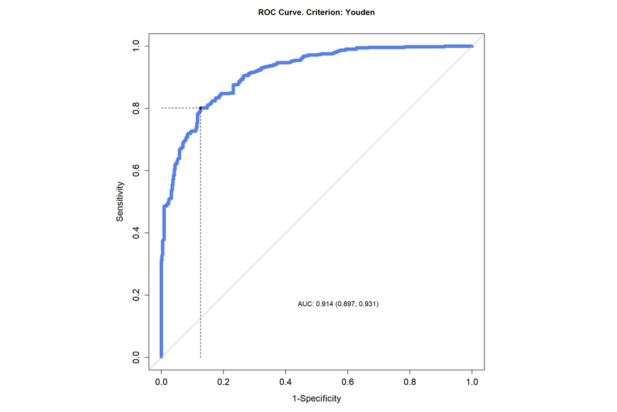

```r
######################################
# Creating a function to gather the
# classification metrics applying the
# threshold criterion using the
# Youden Index
######################################
ClassificationMetrics.Class0.LO.YOUDEN <- function(SourceData,Response,Predictor){
  ThresholdCriterion <- optimal.cutpoints(X = Predictor,
                                         status = Response,
                                         tag.healthy = "Low",
                                         methods = c("Youden"),
                                         data = SourceData,
                                         pop.prev = NULL,
                                         control = control.cutpoints(generalized.Youden=FALSE,
                                                                     costs.benefits.Youden=FALSE),
                                         ci.fit = FALSE,
                                         direction = c("<"))

  summary(ThresholdCriterion)
  (OptimalThreshold <- ThresholdCriterion$Youden$Global$optimal.cutoff$cutoff[1])
  (ThresholdSensitivity <- ThresholdCriterion$Youden$Global$optimal.cutoff$Se[,1][1])
  (ThresholdSpecificity <- ThresholdCriterion$Youden$Global$optimal.cutoff$Sp[,1][1])
  (ThresholdROCAUC <- ThresholdCriterion$Youden$Global$measures.acc$AUC[1])
  plot.optimal.cutpoints(ThresholdCriterion,
                         col=c("#5680E9"),
                         legend=FALSE,
                         which=1,
                         xlim=c(0,1),
                         ylim=c(0,1),
                         lwd=8)
  ClassificationMetricsList <-list(OptimalThreshold,
                                   ThresholdSensitivity,
                                   ThresholdSpecificity,
                                   ThresholdROCAUC)
  return(ClassificationMetricsList)
}

ClassificationMetrics.Class0.HI.YOUDEN <- function(SourceData,Response,Predictor){
  ThresholdCriterion <- optimal.cutpoints(X = Predictor,
                                         status = Response,
                                         tag.healthy = "Low",
                                         methods = c("Youden"),
                                         data = SourceData,
                                         pop.prev = NULL,
                                         control = control.cutpoints(generalized.Youden=FALSE,
                                                                     costs.benefits.Youden=FALSE),
                                         ci.fit = FALSE,
                                         direction = c(">"))

  summary(ThresholdCriterion)
  (OptimalThreshold <- ThresholdCriterion$Youden$Global$optimal.cutoff$cutoff[1])
  (ThresholdSensitivity <- ThresholdCriterion$Youden$Global$optimal.cutoff$Se[,1][1])
  (ThresholdSpecificity <- ThresholdCriterion$Youden$Global$optimal.cutoff$Sp[,1][1])
  (ThresholdROCAUC <- ThresholdCriterion$Youden$Global$measures.acc$AUC[1])
  plot.optimal.cutpoints(ThresholdCriterion,
                         col=c("#5680E9"),
                         legend=FALSE,
                         which=1,
                         xlim=c(0,1),
                         ylim=c(0,1),
                         lwd=8)
  ClassificationMetricsList <-list(OptimalThreshold,
                                   ThresholdSensitivity,
                                   ThresholdSpecificity,
                                   ThresholdROCAUC)
  return(ClassificationMetricsList)
}

######################################
# Gather the classification metrics
######################################
OPTTH.List <- list()
THSEN.List <- list()
THSPE.List <- list()
THAUC.List <- list()
PREDI.List <- list()

for (i in 7:7) {
  Response.i  <- colnames(LR_Model_Predictions)[6]
  Predictor.i <- colnames(LR_Model_Predictions)[i]

  ClassificationMetrics.i <- ClassificationMetrics.Class0.LO.YOUDEN(LR_Model_Predictions,
                                                                    Response.i,
                                                                    Predictor.i)
  OPTTH.i <- as.numeric(as.character(sprintf(ClassificationMetrics.i[1],fmt='%#.5f')))
  THSEN.i <- as.numeric(as.character(sprintf(ClassificationMetrics.i[2],fmt='%#.5f')))
  THSPE.i <- as.numeric(as.character(sprintf(ClassificationMetrics.i[3],fmt='%#.5f')))
  THAUC.i <- as.numeric(as.character(sprintf(ClassificationMetrics.i[4],fmt='%#.5f')))

  PREDI.List <- append(PREDI.List,Predictor.i)
  OPTTH.List <- append(OPTTH.List,OPTTH.i)
  THSEN.List <- append(THSEN.List,THSEN.i)
  THSPE.List <- append(THSPE.List,THSPE.i)
  THAUC.List <- append(THAUC.List,THAUC.i)
}
```

```r
ClassificationMetrics.SUMMARY <- cbind(PREDI.List,
                                       THAUC.List,
                                       OPTTH.List,
                                       THSEN.List,
                                       THSPE.List
)

colnames(ClassificationMetrics.SUMMARY) <- c("Predictor",
                                             "ROCAUC",
                                             "OptimalThreshold.YOUDEN",
                                             "ApparentSensitivity",
                                             "ApparentSpecificity")

YOUDEN.SUMMARY <- as.data.frame(ClassificationMetrics.SUMMARY)
YOUDEN.SUMMARY$ROCAUC <- as.numeric(as.character(YOUDEN.SUMMARY$ROCAUC))
YOUDEN.SUMMARY$ApparentSensitivity <- as.numeric(as.character(YOUDEN.SUMMARY$ApparentSensitivity))
YOUDEN.SUMMARY$ApparentSpecificity <- as.numeric(as.character(YOUDEN.SUMMARY$ApparentSpecificity))

(YOUDEN.Threshold <- YOUDEN.SUMMARY$OptimalThreshold.YOUDEN)
```

```
## $OptimalThreshold.YOUDEN
## [1] 0.64163
```

```r
(YOUDEN.Sensitivity <- YOUDEN.SUMMARY$ApparentSensitivity)
```

```
## [1] 0.80153
```

```r
(YOUDEN.Specificity <- YOUDEN.SUMMARY$ApparentSpecificity)
```

```
## [1] 0.87354
```

### 1.5.8 Threshold Criterion Using Maximum Efficiency (TC_MaxEfficiency)

**Code Chunk | Output**

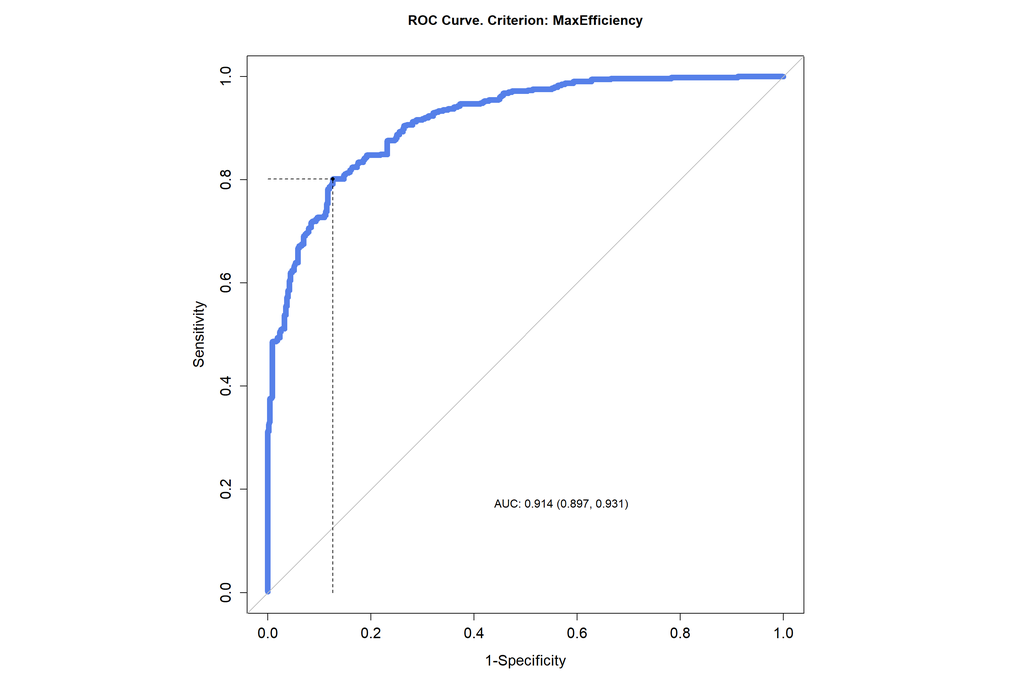

```r
######################################
# Creating a function to gather the
# classification metrics applying the
# threshold criterion which maximizes the
# efficiency or minimizes error rate
######################################
ClassificationMetrics.Class0.LO.MAXEFFICIENCY <- function(SourceData,Response,Predictor){
  ThresholdCriterion <- optimal.cutpoints(X = Predictor,
                                         status = Response,
                                         tag.healthy = "Low",
                                         methods = c("MaxEfficiency"),
                                         data = SourceData,
                                         pop.prev = NULL,
                                         control = control.cutpoints(costs.benefits.Efficiency=TRUE),
                                         ci.fit = FALSE,
                                         direction = c("<"))

  summary(ThresholdCriterion)
  (OptimalThreshold <- ThresholdCriterion$MaxEfficiency$Global$optimal.cutoff$cutoff[1])
  (ThresholdSensitivity <- ThresholdCriterion$MaxEfficiency$Global$optimal.cutoff$Se[,1][1])
  (ThresholdSpecificity <- ThresholdCriterion$MaxEfficiency$Global$optimal.cutoff$Sp[,1][1])
  (ThresholdROCAUC <- ThresholdCriterion$MaxEfficiency$Global$measures.acc$AUC[1])
  plot.optimal.cutpoints(ThresholdCriterion,
                         col=c("#5680E9"),
                         legend=FALSE,
                         which=1,
                         xlim=c(0,1),
                         ylim=c(0,1),
                         lwd=8)
  ClassificationMetricsList <-list(OptimalThreshold,
                                   ThresholdSensitivity,
                                   ThresholdSpecificity,
                                   ThresholdROCAUC)
  return(ClassificationMetricsList)
}

ClassificationMetrics.Class0.HI.MAXEFFICIENCY <- function(SourceData,Response,Predictor){
  ThresholdCriterion <- optimal.cutpoints(X = Predictor,
                                         status = Response,
                                         tag.healthy = "Low",
                                         methods = c("MaxEfficiency"),
                                         data = SourceData,
                                         pop.prev = NULL,
                                         control = control.cutpoints(costs.benefits.Efficiency=TRUE),
                                         ci.fit = FALSE,
                                         direction = c(">"))

  summary(ThresholdCriterion)
  (OptimalThreshold <- ThresholdCriterion$MaxEfficiency$Global$optimal.cutoff$cutoff[1])
  (ThresholdSensitivity <- ThresholdCriterion$MaxEfficiency$Global$optimal.cutoff$Se[,1][1])
  (ThresholdSpecificity <- ThresholdCriterion$MaxEfficiency$Global$optimal.cutoff$Sp[,1][1])
  (ThresholdROCAUC <- ThresholdCriterion$MaxEfficiency$Global$measures.acc$AUC[1])
  plot.optimal.cutpoints(ThresholdCriterion,
                         col=c("#5680E9"),
                         legend=FALSE,
                         which=1,
                         xlim=c(0,1),
                         ylim=c(0,1),
                         lwd=8)
  ClassificationMetricsList <-list(OptimalThreshold,
                                   ThresholdSensitivity,
                                   ThresholdSpecificity,
                                   ThresholdROCAUC)
  return(ClassificationMetricsList)
}

######################################
# Gather the classification metrics
######################################
OPTTH.List <- list()
THSEN.List <- list()
THSPE.List <- list()
THAUC.List <- list()
PREDI.List <- list()

for (i in 7:7) {
  Response.i  <- colnames(LR_Model_Predictions)[6]
  Predictor.i <- colnames(LR_Model_Predictions)[i]

  ClassificationMetrics.i <- ClassificationMetrics.Class0.LO.MAXEFFICIENCY(LR_Model_Predictions,
                                                                    Response.i,
                                                                    Predictor.i)
  OPTTH.i <- as.numeric(as.character(sprintf(ClassificationMetrics.i[1],fmt='%#.5f')))
  THSEN.i <- as.numeric(as.character(sprintf(ClassificationMetrics.i[2],fmt='%#.5f')))
  THSPE.i <- as.numeric(as.character(sprintf(ClassificationMetrics.i[3],fmt='%#.5f')))
  THAUC.i <- as.numeric(as.character(sprintf(ClassificationMetrics.i[4],fmt='%#.5f')))

  PREDI.List <- append(PREDI.List,Predictor.i)
  OPTTH.List <- append(OPTTH.List,OPTTH.i)
  THSEN.List <- append(THSEN.List,THSEN.i)
  THSPE.List <- append(THSPE.List,THSPE.i)
  THAUC.List <- append(THAUC.List,THAUC.i)
}
```

```r
ClassificationMetrics.SUMMARY <- cbind(PREDI.List,
                                       THAUC.List,
                                       OPTTH.List,
                                       THSEN.List,
                                       THSPE.List
)

colnames(ClassificationMetrics.SUMMARY) <- c("Predictor",
                                             "ROCAUC",
                                             "OptimalThreshold.MAXEFFICIENCY",
                                             "ApparentSensitivity",
                                             "ApparentSpecificity")

MAXEFFICIENCY.SUMMARY <- as.data.frame(ClassificationMetrics.SUMMARY)
MAXEFFICIENCY.SUMMARY$ROCAUC <- as.numeric(as.character(MAXEFFICIENCY.SUMMARY$ROCAUC))
MAXEFFICIENCY.SUMMARY$ApparentSensitivity <- as.numeric(as.character(MAXEFFICIENCY.SUMMARY$ApparentSensitivity))
MAXEFFICIENCY.SUMMARY$ApparentSpecificity <- as.numeric(as.character(MAXEFFICIENCY.SUMMARY$ApparentSpecificity))

(MAXEFFICIENCY.Threshold <- MAXEFFICIENCY.SUMMARY$OptimalThreshold.MAXEFFICIENCY)
```

```
## $OptimalThreshold.MAXEFFICIENCY
## [1] 0.64163
```

```r
(MAXEFFICIENCY.Sensitivity <- MAXEFFICIENCY.SUMMARY$ApparentSensitivity)
```

```
## [1] 0.80153
```

```r
(MAXEFFICIENCY.Specificity <- MAXEFFICIENCY.SUMMARY$ApparentSpecificity)
```

```
## [1] 0.87354
```

### 1.5.9 Threshold Criterion Using Minimization of Most Frequent Error (TC_Minimax)

[Minimization of Most Frequent Error](https://www.jstor.org/stable/2347839?origin=crossref) is a threshold criterion based on the optimally lowest most frequent error. In a case where there is more than one cutpoint fulfilling this condition, those which yield maximum Sensitivity or maximum Specificity are chosen.  
**[A]** The Minimax threshold criterion from the **OptimalCutpoints** package was used which minimizes the most frequent error.  
**[B]** The threshold criterion does not require to set any parameter.  
**[C]** The determined optimal dichotomization threshold and corresponding classification metrics are summarized as follows:  
**[C.1]** Log Solubility Class Probability Threshold = 0.56057  
**[C.2]** Apparent Sensitivity = 0.84351  
**[C.3]** Apparent Specificity = 0.81030

**Code Chunk | Output**

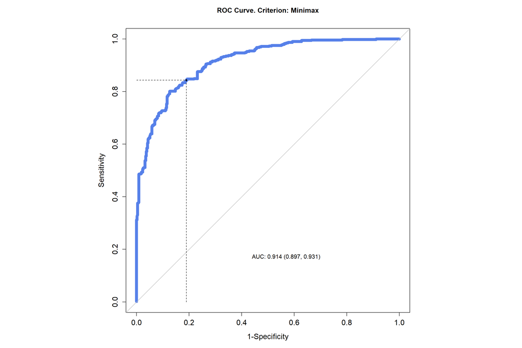

```r
######################################
# Creating a function to gather the
# classification metrics applying the
# threshold criterion which minimizes the
# most frequent error
######################################
ClassificationMetrics.Class0.LO.MINIMAX <- function(SourceData,Response,Predictor){
  ThresholdCriterion <- optimal.cutpoints(X = Predictor,
                                         status = Response,
                                         tag.healthy = "Low",
                                         methods = c("Minimax"),
                                         data = SourceData,
                                         pop.prev = NULL,
                                         ci.fit = FALSE,
                                         direction = c("<"))

  summary(ThresholdCriterion)
  (OptimalThreshold <- ThresholdCriterion$Minimax$Global$optimal.cutoff$cutoff[1])
  (ThresholdSensitivity <- ThresholdCriterion$Minimax$Global$optimal.cutoff$Se[,1][1])
  (ThresholdSpecificity <- ThresholdCriterion$Minimax$Global$optimal.cutoff$Sp[,1][1])
  (ThresholdROCAUC <- ThresholdCriterion$Minimax$Global$measures.acc$AUC[1])
  plot.optimal.cutpoints(ThresholdCriterion,
                         col=c("#5680E9"),
                         legend=FALSE,
                         which=1,
                         xlim=c(0,1),
                         ylim=c(0,1),
                         lwd=8)
  ClassificationMetricsList <-list(OptimalThreshold,
                                   ThresholdSensitivity,
                                   ThresholdSpecificity,
                                   ThresholdROCAUC)
  return(ClassificationMetricsList)
}

ClassificationMetrics.Class0.HI.MINIMAX <- function(SourceData,Response,Predictor){
  ThresholdCriterion <- optimal.cutpoints(X = Predictor,
                                         status = Response,
                                         tag.healthy = "Low",
                                         methods = c("Minimax"),
                                         data = SourceData,
                                         pop.prev = NULL,
                                         ci.fit = FALSE,
                                         direction = c(">"))

  summary(ThresholdCriterion)
  (OptimalThreshold <- ThresholdCriterion$Minimax$Global$optimal.cutoff$cutoff[1])
  (ThresholdSensitivity <- ThresholdCriterion$Minimax$Global$optimal.cutoff$Se[,1][1])
  (ThresholdSpecificity <- ThresholdCriterion$Minimax$Global$optimal.cutoff$Sp[,1][1])
  (ThresholdROCAUC <- ThresholdCriterion$Minimax$Global$measures.acc$AUC[1])
  plot.optimal.cutpoints(ThresholdCriterion,
                         col=c("#5680E9"),
                         legend=FALSE,
                         which=1,
                         xlim=c(0,1),
                         ylim=c(0,1),
                         lwd=8)
  ClassificationMetricsList <-list(OptimalThreshold,
                                   ThresholdSensitivity,
                                   ThresholdSpecificity,
                                   ThresholdROCAUC)
  return(ClassificationMetricsList)
}

######################################
# Gather the classification metrics
######################################
OPTTH.List <- list()
THSEN.List <- list()
THSPE.List <- list()
THAUC.List <- list()
PREDI.List <- list()

for (i in 7:7) {
  Response.i  <- colnames(LR_Model_Predictions)[6]
  Predictor.i <- colnames(LR_Model_Predictions)[i]

  ClassificationMetrics.i <- ClassificationMetrics.Class0.LO.MINIMAX(LR_Model_Predictions,
                                                                    Response.i,
                                                                    Predictor.i)
  OPTTH.i <- as.numeric(as.character(sprintf(ClassificationMetrics.i[1],fmt='%#.5f')))
  THSEN.i <- as.numeric(as.character(sprintf(ClassificationMetrics.i[2],fmt='%#.5f')))
  THSPE.i <- as.numeric(as.character(sprintf(ClassificationMetrics.i[3],fmt='%#.5f')))
  THAUC.i <- as.numeric(as.character(sprintf(ClassificationMetrics.i[4],fmt='%#.5f')))

  PREDI.List <- append(PREDI.List,Predictor.i)
  OPTTH.List <- append(OPTTH.List,OPTTH.i)
  THSEN.List <- append(THSEN.List,THSEN.i)
  THSPE.List <- append(THSPE.List,THSPE.i)
  THAUC.List <- append(THAUC.List,THAUC.i)
}
```

```r
ClassificationMetrics.SUMMARY <- cbind(PREDI.List,
                                       THAUC.List,
                                       OPTTH.List,
                                       THSEN.List,
                                       THSPE.List
)

colnames(ClassificationMetrics.SUMMARY) <- c("Predictor",
                                             "ROCAUC",
                                             "OptimalThreshold.MINIMAX",
                                             "ApparentSensitivity",
                                             "ApparentSpecificity")

MINIMAX.SUMMARY <- as.data.frame(ClassificationMetrics.SUMMARY)
MINIMAX.SUMMARY$ROCAUC <- as.numeric(as.character(MINIMAX.SUMMARY$ROCAUC))
MINIMAX.SUMMARY$ApparentSensitivity <- as.numeric(as.character(MINIMAX.SUMMARY$ApparentSensitivity))
MINIMAX.SUMMARY$ApparentSpecificity <- as.numeric(as.character(MINIMAX.SUMMARY$ApparentSpecificity))

(MINIMAX.Threshold <- MINIMAX.SUMMARY$OptimalThreshold.MINIMAX)
```

```
## $OptimalThreshold.MINIMAX
## [1] 0.56057
```

```r
(MINIMAX.Sensitivity <- MINIMAX.SUMMARY$ApparentSensitivity)
```

```
## [1] 0.84351
```

```r
(MINIMAX.Specificity <- MINIMAX.SUMMARY$ApparentSpecificity)
```

```
## [1] 0.8103
```

### 1.5.10 Threshold Criterion Using Maximum Diagnostic Odds Ratio (TC_MaxDOR)

[Maximum Diagnostic Odds Ratio](https://us.sagepub.com/en-us/nam/evaluating-medical-tests/book3306) is a threshold criterion based on the optimally highest Diagnostic Odds Ratio (DOR).  
**[A]** The MaxDOR threshold criterion from the **OptimalCutpoints** package was used which maximizes the Diagnostic Odds Ratio.  
**[B]** The threshold criterion does not require to set any parameter.  
**[C]** The determined optimal dichotomization threshold and corresponding classification metrics are summarized as follows:  
**[C.1]** Log Solubility Class Probability Threshold = 0.92748  
**[C.2]** Apparent Sensitivity = 0.31298  
**[C.3]** Apparent Specificity = 1.00000

**Code Chunk | Output**

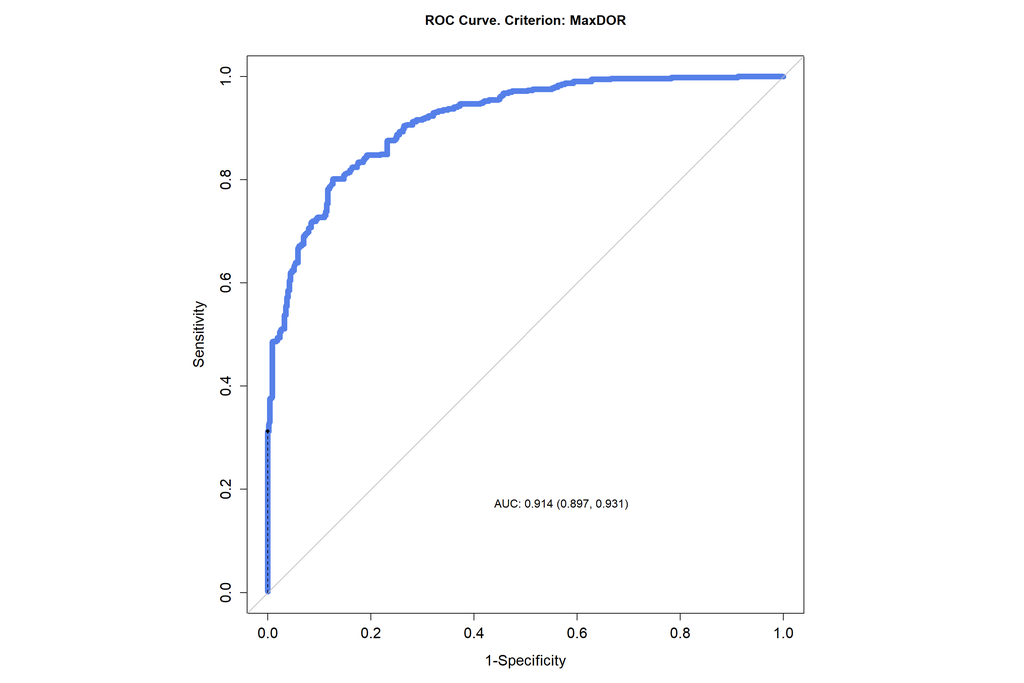

```r
######################################
# Creating a function to gather the
# classification metrics applying the
# threshold criterion which maximizes the
# Diagnostic Odds Ratio
######################################
ClassificationMetrics.Class0.LO.MAXDOR <- function(SourceData,Response,Predictor){
  ThresholdCriterion <- optimal.cutpoints(X = Predictor,
                                         status = Response,
                                         tag.healthy = "Low",
                                         methods = c("MaxDOR"),
                                         data = SourceData,
                                         pop.prev = NULL,
                                         ci.fit = FALSE,
                                         direction = c("<"))

  summary(ThresholdCriterion)
  (OptimalThreshold <- ThresholdCriterion$MaxDOR$Global$optimal.cutoff$cutoff[1])
  (ThresholdSensitivity <- ThresholdCriterion$MaxDOR$Global$optimal.cutoff$Se[,1][1])
  (ThresholdSpecificity <- ThresholdCriterion$MaxDOR$Global$optimal.cutoff$Sp[,1][1])
  (ThresholdROCAUC <- ThresholdCriterion$MaxDOR$Global$measures.acc$AUC[1])
  plot.optimal.cutpoints(ThresholdCriterion,
                         col=c("#5680E9"),
                         legend=FALSE,
                         which=1,
                         xlim=c(0,1),
                         ylim=c(0,1),
                         lwd=8)
  ClassificationMetricsList <-list(OptimalThreshold,
                                   ThresholdSensitivity,
                                   ThresholdSpecificity,
                                   ThresholdROCAUC)
  return(ClassificationMetricsList)
}

ClassificationMetrics.Class0.HI.MAXDOR <- function(SourceData,Response,Predictor){
  ThresholdCriterion <- optimal.cutpoints(X = Predictor,
                                         status = Response,
                                         tag.healthy = "Low",
                                         methods = c("MaxDOR"),
                                         data = SourceData,
                                         pop.prev = NULL,
                                         ci.fit = FALSE,
                                         direction = c(">"))

  summary(ThresholdCriterion)
  (OptimalThreshold <- ThresholdCriterion$MaxDOR$Global$optimal.cutoff$cutoff[1])
  (ThresholdSensitivity <- ThresholdCriterion$MaxDOR$Global$optimal.cutoff$Se[,1][1])
  (ThresholdSpecificity <- ThresholdCriterion$MaxDOR$Global$optimal.cutoff$Sp[,1][1])
  (ThresholdROCAUC <- ThresholdCriterion$MaxDOR$Global$measures.acc$AUC[1])
  plot.optimal.cutpoints(ThresholdCriterion,
                         col=c("#5680E9"),
                         legend=FALSE,
                         which=1,
                         xlim=c(0,1),
                         ylim=c(0,1),
                         lwd=8)
  ClassificationMetricsList <-list(OptimalThreshold,
                                   ThresholdSensitivity,
                                   ThresholdSpecificity,
                                   ThresholdROCAUC)
  return(ClassificationMetricsList)
}

######################################
# Gather the classification metrics
######################################
OPTTH.List <- list()
THSEN.List <- list()
THSPE.List <- list()
THAUC.List <- list()
PREDI.List <- list()

for (i in 7:7) {
  Response.i  <- colnames(LR_Model_Predictions)[6]
  Predictor.i <- colnames(LR_Model_Predictions)[i]

  ClassificationMetrics.i <- ClassificationMetrics.Class0.LO.MAXDOR(LR_Model_Predictions,
                                                                    Response.i,
                                                                    Predictor.i)
  OPTTH.i <- as.numeric(as.character(sprintf(ClassificationMetrics.i[1],fmt='%#.5f')))
  THSEN.i <- as.numeric(as.character(sprintf(ClassificationMetrics.i[2],fmt='%#.5f')))
  THSPE.i <- as.numeric(as.character(sprintf(ClassificationMetrics.i[3],fmt='%#.5f')))
  THAUC.i <- as.numeric(as.character(sprintf(ClassificationMetrics.i[4],fmt='%#.5f')))

  PREDI.List <- append(PREDI.List,Predictor.i)
  OPTTH.List <- append(OPTTH.List,OPTTH.i)
  THSEN.List <- append(THSEN.List,THSEN.i)
  THSPE.List <- append(THSPE.List,THSPE.i)
  THAUC.List <- append(THAUC.List,THAUC.i)
}
```

```r
ClassificationMetrics.SUMMARY <- cbind(PREDI.List,
                                       THAUC.List,
                                       OPTTH.List,
                                       THSEN.List,
                                       THSPE.List
)

colnames(ClassificationMetrics.SUMMARY) <- c("Predictor",
                                             "ROCAUC",
                                             "OptimalThreshold.MAXDOR",
                                             "ApparentSensitivity",
                                             "ApparentSpecificity")

MAXDOR.SUMMARY <- as.data.frame(ClassificationMetrics.SUMMARY)
MAXDOR.SUMMARY$ROCAUC <- as.numeric(as.character(MAXDOR.SUMMARY$ROCAUC))
MAXDOR.SUMMARY$ApparentSensitivity <- as.numeric(as.character(MAXDOR.SUMMARY$ApparentSensitivity))
MAXDOR.SUMMARY$ApparentSpecificity <- as.numeric(as.character(MAXDOR.SUMMARY$ApparentSpecificity))

(MAXDOR.Threshold <- MAXDOR.SUMMARY$OptimalThreshold.MAXDOR)
```

```
## $OptimalThreshold.MAXDOR
## [1] 0.92748
```

```r
(MAXDOR.Sensitivity <- MAXDOR.SUMMARY$ApparentSensitivity)
```

```
## [1] 0.31298
```

```r
(MAXDOR.Specificity <- MAXDOR.SUMMARY$ApparentSpecificity)
```

```
## [1] 1
```

### 1.5.11 Threshold Criterion Using Maximum Kappa (TC_MaxKappa)

**Code Chunk | Output**

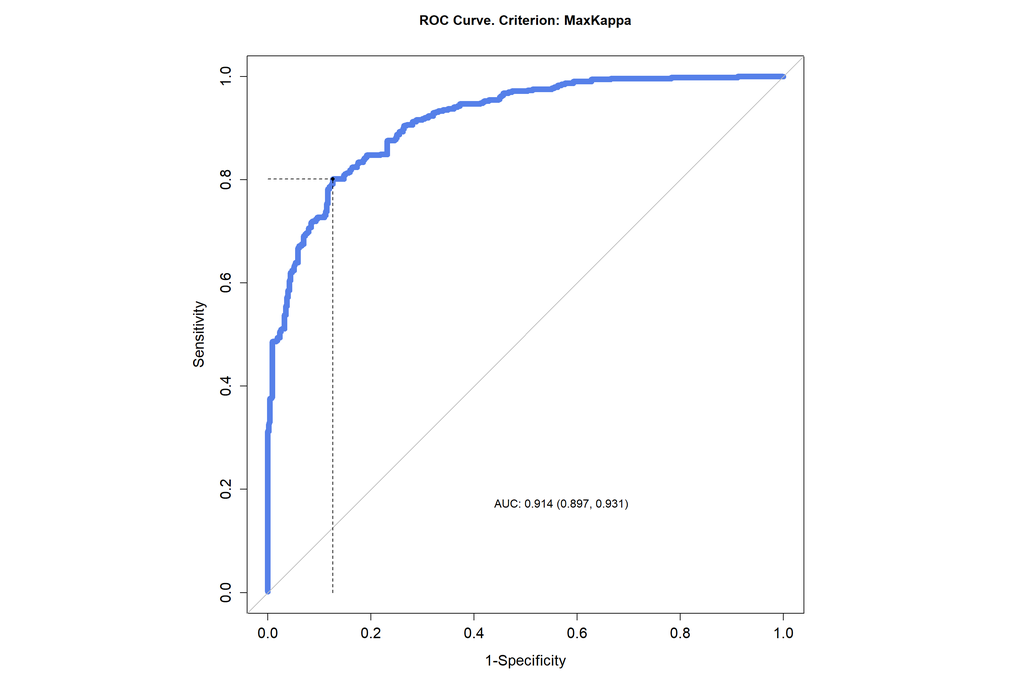

```r
######################################
# Creating a function to gather the
# classification metrics applying the
# threshold criterion which maximizes the
# Kappa Index
######################################
ClassificationMetrics.Class0.LO.MAXKAPPA <- function(SourceData,Response,Predictor){
  ThresholdCriterion <- optimal.cutpoints(X = Predictor,
                                         status = Response,
                                         tag.healthy = "Low",
                                         methods = c("MaxKappa"),
                                         data = SourceData,
                                         pop.prev = NULL,
                                         control = control.cutpoints(weighted.Kappa=FALSE),
                                         ci.fit = FALSE,
                                         direction = c("<"))

  summary(ThresholdCriterion)
  (OptimalThreshold <- ThresholdCriterion$MaxKappa$Global$optimal.cutoff$cutoff[1])
  (ThresholdSensitivity <- ThresholdCriterion$MaxKappa$Global$optimal.cutoff$Se[,1][1])
  (ThresholdSpecificity <- ThresholdCriterion$MaxKappa$Global$optimal.cutoff$Sp[,1][1])
  (ThresholdROCAUC <- ThresholdCriterion$MaxKappa$Global$measures.acc$AUC[1])
  plot.optimal.cutpoints(ThresholdCriterion,
                         col=c("#5680E9"),
                         legend=FALSE,
                         which=1,
                         xlim=c(0,1),
                         ylim=c(0,1),
                         lwd=8)
  ClassificationMetricsList <-list(OptimalThreshold,
                                   ThresholdSensitivity,
                                   ThresholdSpecificity,
                                   ThresholdROCAUC)
  return(ClassificationMetricsList)
}

ClassificationMetrics.Class0.HI.MAXKAPPA <- function(SourceData,Response,Predictor){
  ThresholdCriterion <- optimal.cutpoints(X = Predictor,
                                         status = Response,
                                         tag.healthy = "Low",
                                         methods = c("MaxKappa"),
                                         data = SourceData,
                                         pop.prev = NULL,
                                         control = control.cutpoints(weighted.Kappa=FALSE),
                                         ci.fit = FALSE,
                                         direction = c(">"))

  summary(ThresholdCriterion)
  (OptimalThreshold <- ThresholdCriterion$MaxKappa$Global$optimal.cutoff$cutoff[1])
  (ThresholdSensitivity <- ThresholdCriterion$MaxKappa$Global$optimal.cutoff$Se[,1][1])
  (ThresholdSpecificity <- ThresholdCriterion$MaxKappa$Global$optimal.cutoff$Sp[,1][1])
  (ThresholdROCAUC <- ThresholdCriterion$MaxKappa$Global$measures.acc$AUC[1])
  plot.optimal.cutpoints(ThresholdCriterion,
                         col=c("#5680E9"),
                         legend=FALSE,
                         which=1,
                         xlim=c(0,1),
                         ylim=c(0,1),
                         lwd=8)
  ClassificationMetricsList <-list(OptimalThreshold,
                                   ThresholdSensitivity,
                                   ThresholdSpecificity,
                                   ThresholdROCAUC)
  return(ClassificationMetricsList)
}

######################################
# Gather the classification metrics
######################################
OPTTH.List <- list()
THSEN.List <- list()
THSPE.List <- list()
THAUC.List <- list()
PREDI.List <- list()

for (i in 7:7) {
  Response.i  <- colnames(LR_Model_Predictions)[6]
  Predictor.i <- colnames(LR_Model_Predictions)[i]

  ClassificationMetrics.i <- ClassificationMetrics.Class0.LO.MAXKAPPA(LR_Model_Predictions,
                                                                    Response.i,
                                                                    Predictor.i)
  OPTTH.i <- as.numeric(as.character(sprintf(ClassificationMetrics.i[1],fmt='%#.5f')))
  THSEN.i <- as.numeric(as.character(sprintf(ClassificationMetrics.i[2],fmt='%#.5f')))
  THSPE.i <- as.numeric(as.character(sprintf(ClassificationMetrics.i[3],fmt='%#.5f')))
  THAUC.i <- as.numeric(as.character(sprintf(ClassificationMetrics.i[4],fmt='%#.5f')))

  PREDI.List <- append(PREDI.List,Predictor.i)
  OPTTH.List <- append(OPTTH.List,OPTTH.i)
  THSEN.List <- append(THSEN.List,THSEN.i)
  THSPE.List <- append(THSPE.List,THSPE.i)
  THAUC.List <- append(THAUC.List,THAUC.i)
}
```

```r
ClassificationMetrics.SUMMARY <- cbind(PREDI.List,
                                       THAUC.List,
                                       OPTTH.List,
                                       THSEN.List,
                                       THSPE.List
)

colnames(ClassificationMetrics.SUMMARY) <- c("Predictor",
                                             "ROCAUC",
                                             "OptimalThreshold.MAXKAPPA",
                                             "ApparentSensitivity",
                                             "ApparentSpecificity")

MAXKAPPA.SUMMARY <- as.data.frame(ClassificationMetrics.SUMMARY)
MAXKAPPA.SUMMARY$ROCAUC <- as.numeric(as.character(MAXKAPPA.SUMMARY$ROCAUC))
MAXKAPPA.SUMMARY$ApparentSensitivity <- as.numeric(as.character(MAXKAPPA.SUMMARY$ApparentSensitivity))
MAXKAPPA.SUMMARY$ApparentSpecificity <- as.numeric(as.character(MAXKAPPA.SUMMARY$ApparentSpecificity))

(MAXKAPPA.Threshold <- MAXKAPPA.SUMMARY$OptimalThreshold.MAXKAPPA)
```

```
## $OptimalThreshold.MAXKAPPA
## [1] 0.64163
```

```r
(MAXKAPPA.Sensitivity <- MAXKAPPA.SUMMARY$ApparentSensitivity)
```

```
## [1] 0.80153
```

```r
(MAXKAPPA.Specificity <- MAXKAPPA.SUMMARY$ApparentSpecificity)
```

```
## [1] 0.87354
```

### 1.5.12 Threshold Criterion Using Minimum Negative Predictive Value (TC_MinValueNPV)

[Minimum Negative Predictive Value](https://www.sciencedirect.com/science/article/abs/pii/0169260791900722?via%3Dihub) is a threshold criterion based on setting a minimum value for Negative Predictive Value. In a case where there is more than one cutpoint fulfilling this condition, those which yield the maximum Positive Predictive Value are chosen. If several cutpoints still remain, those yielding the highest Negative Predictive Value are chosen.  
**[A]** The MinValueNPV threshold criterion from the **OptimalCutpoints** package was used which applies a minimum value set for negative predictive value.  
**[B]** The threshold criterion requires to set 1 parameter:  
**[B.1]** valueNPV = minimum NPV value set at 0.90  
**[C]** The determined optimal dichotomization threshold and corresponding classification metrics are summarized as follows:  
**[C.1]** Log Solubility Class Probability Threshold = 0.31952  
**[C.2]** Apparent Sensitivity = 0.94656  
**[C.3]** Apparent Specificity = 0.62763

**Code Chunk | Output**

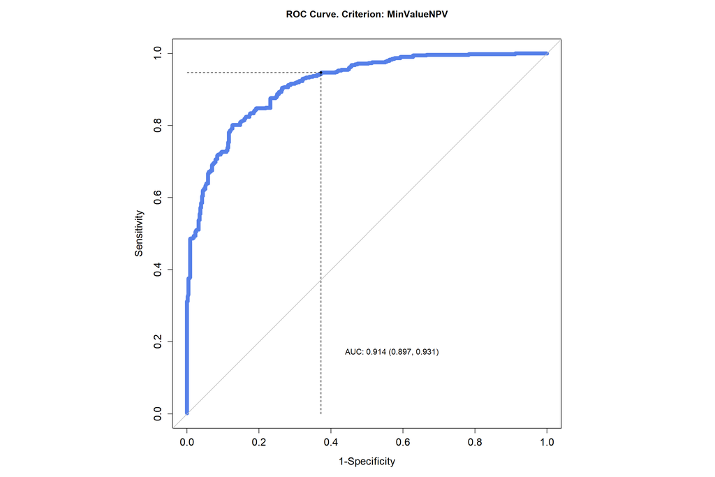

```r
######################################
# Creating a function to gather the
# classification metrics applying the
# threshold criterion using a
# minimum value set for negative predictive value
######################################
ClassificationMetrics.Class0.LO.MINVALUENPV <- function(SourceData,Response,Predictor){
  ThresholdCriterion <- optimal.cutpoints(X = Predictor,
                                         status = Response,
                                         tag.healthy = "Low",
                                         methods = c("MinValueNPV"),
                                         data = SourceData,
                                         pop.prev = NULL,
                                         control = control.cutpoints(valueNPV=0.90),
                                         ci.fit = FALSE,
                                         direction = c("<"))

  summary(ThresholdCriterion)
  (OptimalThreshold <- ThresholdCriterion$MinValueNPV$Global$optimal.cutoff$cutoff[1])
  (ThresholdSensitivity <- ThresholdCriterion$MinValueNPV$Global$optimal.cutoff$Se[,1][1])
  (ThresholdSpecificity <- ThresholdCriterion$MinValueNPV$Global$optimal.cutoff$Sp[,1][1])
  (ThresholdROCAUC <- ThresholdCriterion$MinValueNPV$Global$measures.acc$AUC[1])
  plot.optimal.cutpoints(ThresholdCriterion,
                         col=c("#5680E9"),
                         legend=FALSE,
                         which=1,
                         xlim=c(0,1),
                         ylim=c(0,1),
                         lwd=8)
  ClassificationMetricsList <-list(OptimalThreshold,
                                   ThresholdSensitivity,
                                   ThresholdSpecificity,
                                   ThresholdROCAUC)
  return(ClassificationMetricsList)
}

ClassificationMetrics.Class0.HI.MINVALUENPV <- function(SourceData,Response,Predictor){
  ThresholdCriterion <- optimal.cutpoints(X = Predictor,
                                         status = Response,
                                         tag.healthy = "Low",
                                         methods = c("MinValueNPV"),
                                         data = SourceData,
                                         pop.prev = NULL,
                                         control = control.cutpoints(valueNPV=0.90),
                                         ci.fit = FALSE,
                                         direction = c(">"))

  summary(ThresholdCriterion)
  (OptimalThreshold <- ThresholdCriterion$MinValueNPV$Global$optimal.cutoff$cutoff[1])
  (ThresholdSensitivity <- ThresholdCriterion$MinValueNPV$Global$optimal.cutoff$Se[,1][1])
  (ThresholdSpecificity <- ThresholdCriterion$MinValueNPV$Global$optimal.cutoff$Sp[,1][1])
  (ThresholdROCAUC <- ThresholdCriterion$MinValueNPV$Global$measures.acc$AUC[1])
  plot.optimal.cutpoints(ThresholdCriterion,
                         col=c("#5680E9"),
                         legend=FALSE,
                         which=1,
                         xlim=c(0,1),
                         ylim=c(0,1),
                         lwd=8)
  ClassificationMetricsList <-list(OptimalThreshold,
                                   ThresholdSensitivity,
                                   ThresholdSpecificity,
                                   ThresholdROCAUC)
  return(ClassificationMetricsList)
}

######################################
# Gather the classification metrics
######################################
OPTTH.List <- list()
THSEN.List <- list()
THSPE.List <- list()
THAUC.List <- list()
PREDI.List <- list()

for (i in 7:7) {
  Response.i  <- colnames(LR_Model_Predictions)[6]
  Predictor.i <- colnames(LR_Model_Predictions)[i]

  ClassificationMetrics.i <- ClassificationMetrics.Class0.LO.MINVALUENPV(LR_Model_Predictions,
                                                                    Response.i,
                                                                    Predictor.i)
  OPTTH.i <- as.numeric(as.character(sprintf(ClassificationMetrics.i[1],fmt='%#.5f')))
  THSEN.i <- as.numeric(as.character(sprintf(ClassificationMetrics.i[2],fmt='%#.5f')))
  THSPE.i <- as.numeric(as.character(sprintf(ClassificationMetrics.i[3],fmt='%#.5f')))
  THAUC.i <- as.numeric(as.character(sprintf(ClassificationMetrics.i[4],fmt='%#.5f')))

  PREDI.List <- append(PREDI.List,Predictor.i)
  OPTTH.List <- append(OPTTH.List,OPTTH.i)
  THSEN.List <- append(THSEN.List,THSEN.i)
  THSPE.List <- append(THSPE.List,THSPE.i)
  THAUC.List <- append(THAUC.List,THAUC.i)
}
```

```r
ClassificationMetrics.SUMMARY <- cbind(PREDI.List,
                                       THAUC.List,
                                       OPTTH.List,
                                       THSEN.List,
                                       THSPE.List
)

colnames(ClassificationMetrics.SUMMARY) <- c("Predictor",
                                             "ROCAUC",
                                             "OptimalThreshold.MINVALUENPV",
                                             "ApparentSensitivity",
                                             "ApparentSpecificity")

MINVALUENPV.SUMMARY <- as.data.frame(ClassificationMetrics.SUMMARY)
MINVALUENPV.SUMMARY$ROCAUC <- as.numeric(as.character(MINVALUENPV.SUMMARY$ROCAUC))
MINVALUENPV.SUMMARY$ApparentSensitivity <- as.numeric(as.character(MINVALUENPV.SUMMARY$ApparentSensitivity))
MINVALUENPV.SUMMARY$ApparentSpecificity <- as.numeric(as.character(MINVALUENPV.SUMMARY$ApparentSpecificity))

(MINVALUENPV.Threshold <- MINVALUENPV.SUMMARY$OptimalThreshold.MINVALUENPV)
```

```
## $OptimalThreshold.MINVALUENPV
## [1] 0.31952
```

```r
(MINVALUENPV.Sensitivity <- MINVALUENPV.SUMMARY$ApparentSensitivity)
```

```
## [1] 0.94656
```

```r
(MINVALUENPV.Specificity <- MINVALUENPV.SUMMARY$ApparentSpecificity)
```

```
## [1] 0.62763
```

### 1.5.13 Threshold Criterion Using Minimum Positive Predictive Value (TC_MinValuePPV)

**Code Chunk | Output**

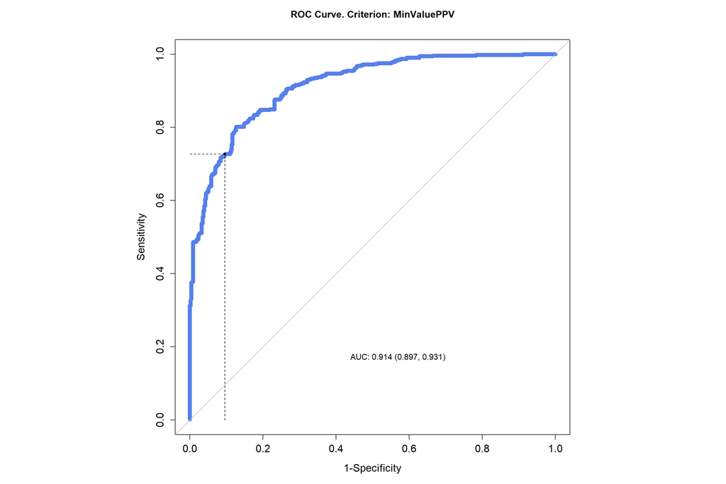

```r
######################################
# Creating a function to gather the
# classification metrics applying the
# threshold criterion using a
# minimum value set for positive predictive value
######################################
ClassificationMetrics.Class0.LO.MINVALUEPPV <- function(SourceData,Response,Predictor){
  ThresholdCriterion <- optimal.cutpoints(X = Predictor,
                                         status = Response,
                                         tag.healthy = "Low",
                                         methods = c("MinValuePPV"),
                                         data = SourceData,
                                         pop.prev = NULL,
                                         control = control.cutpoints(valuePPV=0.90),
                                         ci.fit = FALSE,
                                         direction = c("<"))

  summary(ThresholdCriterion)
  (OptimalThreshold <- ThresholdCriterion$MinValuePPV$Global$optimal.cutoff$cutoff[1])
  (ThresholdSensitivity <- ThresholdCriterion$MinValuePPV$Global$optimal.cutoff$Se[,1][1])
  (ThresholdSpecificity <- ThresholdCriterion$MinValuePPV$Global$optimal.cutoff$Sp[,1][1])
  (ThresholdROCAUC <- ThresholdCriterion$MinValuePPV$Global$measures.acc$AUC[1])
  plot.optimal.cutpoints(ThresholdCriterion,
                         col=c("#5680E9"),
                         legend=FALSE,
                         which=1,
                         xlim=c(0,1),
                         ylim=c(0,1),
                         lwd=8)
  ClassificationMetricsList <-list(OptimalThreshold,
                                   ThresholdSensitivity,
                                   ThresholdSpecificity,
                                   ThresholdROCAUC)
  return(ClassificationMetricsList)
}

ClassificationMetrics.Class0.HI.MINVALUEPPV <- function(SourceData,Response,Predictor){
  ThresholdCriterion <- optimal.cutpoints(X = Predictor,
                                         status = Response,
                                         tag.healthy = "Low",
                                         methods = c("MinValuePPV"),
                                         data = SourceData,
                                         pop.prev = NULL,
                                         control = control.cutpoints(valuePPV=0.90),
                                         ci.fit = FALSE,
                                         direction = c(">"))

  summary(ThresholdCriterion)
  (OptimalThreshold <- ThresholdCriterion$MinValuePPV$Global$optimal.cutoff$cutoff[1])
  (ThresholdSensitivity <- ThresholdCriterion$MinValuePPV$Global$optimal.cutoff$Se[,1][1])
  (ThresholdSpecificity <- ThresholdCriterion$MinValuePPV$Global$optimal.cutoff$Sp[,1][1])
  (ThresholdROCAUC <- ThresholdCriterion$MinValuePPV$Global$measures.acc$AUC[1])
  plot.optimal.cutpoints(ThresholdCriterion,
                         col=c("#5680E9"),
                         legend=FALSE,
                         which=1,
                         xlim=c(0,1),
                         ylim=c(0,1),
                         lwd=8)
  ClassificationMetricsList <-list(OptimalThreshold,
                                   ThresholdSensitivity,
                                   ThresholdSpecificity,
                                   ThresholdROCAUC)
  return(ClassificationMetricsList)
}

######################################
# Gather the classification metrics
######################################
OPTTH.List <- list()
THSEN.List <- list()
THSPE.List <- list()
THAUC.List <- list()
PREDI.List <- list()

for (i in 7:7) {
  Response.i  <- colnames(LR_Model_Predictions)[6]
  Predictor.i <- colnames(LR_Model_Predictions)[i]

  ClassificationMetrics.i <- ClassificationMetrics.Class0.LO.MINVALUEPPV(LR_Model_Predictions,
                                                                    Response.i,
                                                                    Predictor.i)
  OPTTH.i <- as.numeric(as.character(sprintf(ClassificationMetrics.i[1],fmt='%#.5f')))
  THSEN.i <- as.numeric(as.character(sprintf(ClassificationMetrics.i[2],fmt='%#.5f')))
  THSPE.i <- as.numeric(as.character(sprintf(ClassificationMetrics.i[3],fmt='%#.5f')))
  THAUC.i <- as.numeric(as.character(sprintf(ClassificationMetrics.i[4],fmt='%#.5f')))

  PREDI.List <- append(PREDI.List,Predictor.i)
  OPTTH.List <- append(OPTTH.List,OPTTH.i)
  THSEN.List <- append(THSEN.List,THSEN.i)
  THSPE.List <- append(THSPE.List,THSPE.i)
  THAUC.List <- append(THAUC.List,THAUC.i)
}
```

```r
ClassificationMetrics.SUMMARY <- cbind(PREDI.List,
                                       THAUC.List,
                                       OPTTH.List,
                                       THSEN.List,
                                       THSPE.List
)

colnames(ClassificationMetrics.SUMMARY) <- c("Predictor",
                                             "ROCAUC",
                                             "OptimalThreshold.MINVALUEPPV",
                                             "ApparentSensitivity",
                                             "ApparentSpecificity")

MINVALUEPPV.SUMMARY <- as.data.frame(ClassificationMetrics.SUMMARY)
MINVALUEPPV.SUMMARY$ROCAUC <- as.numeric(as.character(MINVALUEPPV.SUMMARY$ROCAUC))
MINVALUEPPV.SUMMARY$ApparentSensitivity <- as.numeric(as.character(MINVALUEPPV.SUMMARY$ApparentSensitivity))
MINVALUEPPV.SUMMARY$ApparentSpecificity <- as.numeric(as.character(MINVALUEPPV.SUMMARY$ApparentSpecificity))

(MINVALUEPPV.Threshold <- MINVALUEPPV.SUMMARY$OptimalThreshold.MINVALUEPPV)
```

```
## $OptimalThreshold.MINVALUEPPV
## [1] 0.72336
```

```r
(MINVALUEPPV.Sensitivity <- MINVALUEPPV.SUMMARY$ApparentSensitivity)
```

```
## [1] 0.7271
```

```r
(MINVALUEPPV.Specificity <- MINVALUEPPV.SUMMARY$ApparentSpecificity)
```

```
## [1] 0.90398
```

### 1.5.14 Threshold Criterion Using Negative Equals Positive Predictive Values (TC_NPVEqualPPV)

**Code Chunk | Output**

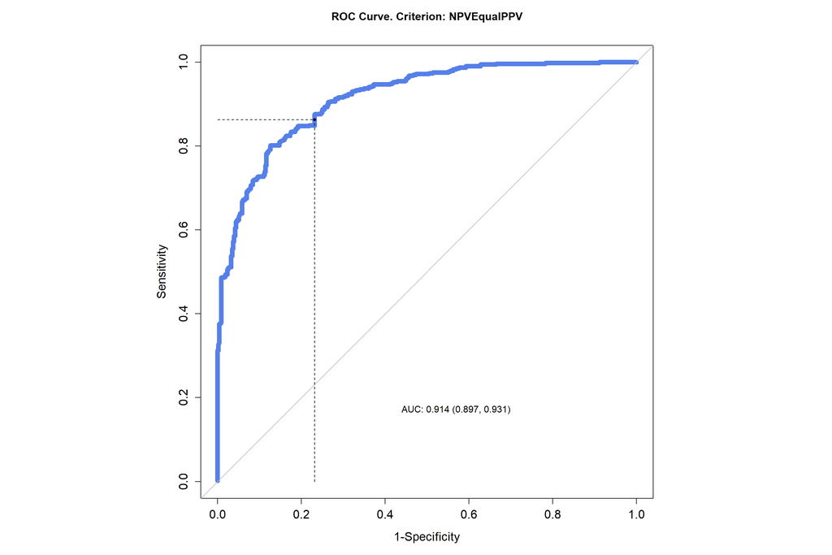

```r
######################################
# Creating a function to gather the
# classification metrics applying the
# threshold criterion using the ROC curve point where
# negative predictive value approximately equals
# positive predictive value
######################################
ClassificationMetrics.Class0.LO.NPVEQUALPPV <- function(SourceData,Response,Predictor){
  ThresholdCriterion <- optimal.cutpoints(X = Predictor,
                                         status = Response,
                                         tag.healthy = "Low",
                                         methods = c("NPVEqualPPV"),
                                         data = SourceData,
                                         pop.prev = NULL,
                                         ci.fit = FALSE,
                                         direction = c("<"))

  summary(ThresholdCriterion)
  (OptimalThreshold <- ThresholdCriterion$NPVEqualPPV$Global$optimal.cutoff$cutoff[1])
  (ThresholdSensitivity <- ThresholdCriterion$NPVEqualPPV$Global$optimal.cutoff$Se[,1][1])
  (ThresholdSpecificity <- ThresholdCriterion$NPVEqualPPV$Global$optimal.cutoff$Sp[,1][1])
  (ThresholdROCAUC <- ThresholdCriterion$NPVEqualPPV$Global$measures.acc$AUC[1])
  plot.optimal.cutpoints(ThresholdCriterion,
                         col=c("#5680E9"),
                         legend=FALSE,
                         which=1,
                         xlim=c(0,1),
                         ylim=c(0,1),
                         lwd=8)
  ClassificationMetricsList <-list(OptimalThreshold,
                                   ThresholdSensitivity,
                                   ThresholdSpecificity,
                                   ThresholdROCAUC)
  return(ClassificationMetricsList)
}

ClassificationMetrics.Class0.HI.NPVEQUALPPV <- function(SourceData,Response,Predictor){
  ThresholdCriterion <- optimal.cutpoints(X = Predictor,
                                         status = Response,
                                         tag.healthy = "Low",
                                         methods = c("NPVEqualPPV"),
                                         data = SourceData,
                                         pop.prev = NULL,
                                         ci.fit = FALSE,
                                         direction = c(">"))

  summary(ThresholdCriterion)
  (OptimalThreshold <- ThresholdCriterion$NPVEqualPPV$Global$optimal.cutoff$cutoff[1])
  (ThresholdSensitivity <- ThresholdCriterion$NPVEqualPPV$Global$optimal.cutoff$Se[,1][1])
  (ThresholdSpecificity <- ThresholdCriterion$NPVEqualPPV$Global$optimal.cutoff$Sp[,1][1])
  (ThresholdROCAUC <- ThresholdCriterion$NPVEqualPPV$Global$measures.acc$AUC[1])
  plot.optimal.cutpoints(ThresholdCriterion,
                         col=c("#5680E9"),
                         legend=FALSE,
                         which=1,
                         xlim=c(0,1),
                         ylim=c(0,1),
                         lwd=8)
  ClassificationMetricsList <-list(OptimalThreshold,
                                   ThresholdSensitivity,
                                   ThresholdSpecificity,
                                   ThresholdROCAUC)
  return(ClassificationMetricsList)
}

######################################
# Gather the classification metrics
######################################
OPTTH.List <- list()
THSEN.List <- list()
THSPE.List <- list()
THAUC.List <- list()
PREDI.List <- list()

for (i in 7:7) {
  Response.i  <- colnames(LR_Model_Predictions)[6]
  Predictor.i <- colnames(LR_Model_Predictions)[i]

  ClassificationMetrics.i <- ClassificationMetrics.Class0.LO.NPVEQUALPPV(LR_Model_Predictions,
                                                                    Response.i,
                                                                    Predictor.i)
  OPTTH.i <- as.numeric(as.character(sprintf(ClassificationMetrics.i[1],fmt='%#.5f')))
  THSEN.i <- as.numeric(as.character(sprintf(ClassificationMetrics.i[2],fmt='%#.5f')))
  THSPE.i <- as.numeric(as.character(sprintf(ClassificationMetrics.i[3],fmt='%#.5f')))
  THAUC.i <- as.numeric(as.character(sprintf(ClassificationMetrics.i[4],fmt='%#.5f')))

  PREDI.List <- append(PREDI.List,Predictor.i)
  OPTTH.List <- append(OPTTH.List,OPTTH.i)
  THSEN.List <- append(THSEN.List,THSEN.i)
  THSPE.List <- append(THSPE.List,THSPE.i)
  THAUC.List <- append(THAUC.List,THAUC.i)
}
```

```r
ClassificationMetrics.SUMMARY <- cbind(PREDI.List,
                                       THAUC.List,
                                       OPTTH.List,
                                       THSEN.List,
                                       THSPE.List
)

colnames(ClassificationMetrics.SUMMARY) <- c("Predictor",
                                             "ROCAUC",
                                             "OptimalThreshold.NPVEQUALPPV",
                                             "ApparentSensitivity",
                                             "ApparentSpecificity")

NPVEQUALPPV.SUMMARY <- as.data.frame(ClassificationMetrics.SUMMARY)
NPVEQUALPPV.SUMMARY$ROCAUC <- as.numeric(as.character(NPVEQUALPPV.SUMMARY$ROCAUC))
NPVEQUALPPV.SUMMARY$ApparentSensitivity <- as.numeric(as.character(NPVEQUALPPV.SUMMARY$ApparentSensitivity))
NPVEQUALPPV.SUMMARY$ApparentSpecificity <- as.numeric(as.character(NPVEQUALPPV.SUMMARY$ApparentSpecificity))

(NPVEQUALPPV.Threshold <- NPVEQUALPPV.SUMMARY$OptimalThreshold.NPVEQUALPPV)
```

```
## $OptimalThreshold.NPVEQUALPPV
## [1] 0.5183
```

```r
(NPVEQUALPPV.Sensitivity <- NPVEQUALPPV.SUMMARY$ApparentSensitivity)
```

```
## [1] 0.8626
```

```r
(NPVEQUALPPV.Specificity <- NPVEQUALPPV.SUMMARY$ApparentSpecificity)
```

```
## [1] 0.76815
```

### 1.5.15 Threshold Criterion Using Minimum P-Value (TC_MinPvalue)

[Minimum P-Value](https://www.jstor.org/stable/2529881?origin=crossref) is a threshold criterion based on the optimally lowest p-value associated with the statistical Chi-squared test which measures the association between the marker and the binary result obtained on using the cutpoint.  
**[A]** The MinPvalue threshold criterion from the **OptimalCutpoints** package was used which minimizes the p-value associated with the statistical Chi-squared test which measures the association between the predictor and the binary result obtained on using the cut-point.  
**[B]** The threshold criterion requires to set 1 parameter:  
**[B.1]** adjusted.pvalue = method for adjusting the p-value value set at PADJMS (p-value adjustment using the method proposed by Miller and Siegmund)  
**[C]** The determined optimal dichotomization threshold and corresponding classification metrics are summarized as follows:  
**[C.1]** Log Solubility Class Probability Threshold = 0.00200  
**[C.2]** Apparent Sensitivity = 1.00000  
**[C.3]** Apparent Specificity = 0.08431

**Code Chunk | Output**

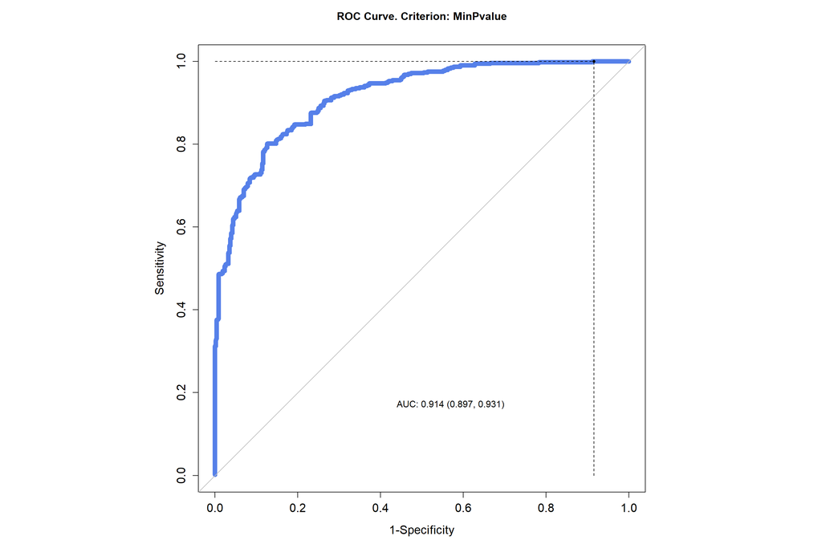

```r
######################################
# Creating a function to gather the
# classification metrics applying the
# threshold criterion which minimizes
# the p-value associated with the statistical Chi-squared test
# which measures the association between the predictor and the
# binary result obtained on using the cut-point
######################################
ClassificationMetrics.Class0.LO.MINPVALUE <- function(SourceData,Response,Predictor){
  ThresholdCriterion <- optimal.cutpoints(X = Predictor,
                                         status = Response,
                                         tag.healthy = "Low",
                                         methods = c("MinPvalue"),
                                         data = SourceData,
                                         pop.prev = NULL,
                                         control = control.cutpoints(adjusted.pvalue = "PADJMS"),
                                         ci.fit = FALSE,
                                         direction = c("<"))

  summary(ThresholdCriterion)
  (OptimalThreshold <- ThresholdCriterion$MinPvalue$Global$optimal.cutoff$cutoff[1])
  (ThresholdSensitivity <- ThresholdCriterion$MinPvalue$Global$optimal.cutoff$Se[,1][1])
  (ThresholdSpecificity <- ThresholdCriterion$MinPvalue$Global$optimal.cutoff$Sp[,1][1])
  (ThresholdROCAUC <- ThresholdCriterion$MinPvalue$Global$measures.acc$AUC[1])
  plot.optimal.cutpoints(ThresholdCriterion,
                         col=c("#5680E9"),
                         legend=FALSE,
                         which=1,
                         xlim=c(0,1),
                         ylim=c(0,1),
                         lwd=8)
  ClassificationMetricsList <-list(OptimalThreshold,
                                   ThresholdSensitivity,
                                   ThresholdSpecificity,
                                   ThresholdROCAUC)
  return(ClassificationMetricsList)
}

ClassificationMetrics.Class0.HI.MINPVALUE <- function(SourceData,Response,Predictor){
  ThresholdCriterion <- optimal.cutpoints(X = Predictor,
                                         status = Response,
                                         tag.healthy = "Low",
                                         methods = c("MinPvalue"),
                                         data = SourceData,
                                         pop.prev = NULL,
                                         control = control.cutpoints(adjusted.pvalue = "PADJMS"),
                                         ci.fit = FALSE,
                                         direction = c(">"))

  summary(ThresholdCriterion)
  (OptimalThreshold <- ThresholdCriterion$MinPvalue$Global$optimal.cutoff$cutoff[1])
  (ThresholdSensitivity <- ThresholdCriterion$MinPvalue$Global$optimal.cutoff$Se[,1][1])
  (ThresholdSpecificity <- ThresholdCriterion$MinPvalue$Global$optimal.cutoff$Sp[,1][1])
  (ThresholdROCAUC <- ThresholdCriterion$MinPvalue$Global$measures.acc$AUC[1])
  plot.optimal.cutpoints(ThresholdCriterion,
                         col=c("#5680E9"),
                         legend=FALSE,
                         which=1,
                         xlim=c(0,1),
                         ylim=c(0,1),
                         lwd=8)
  ClassificationMetricsList <-list(OptimalThreshold,
                                   ThresholdSensitivity,
                                   ThresholdSpecificity,
                                   ThresholdROCAUC)
  return(ClassificationMetricsList)
}

######################################
# Gather the classification metrics
######################################
OPTTH.List <- list()
THSEN.List <- list()
THSPE.List <- list()
THAUC.List <- list()
PREDI.List <- list()

for (i in 7:7) {
  Response.i  <- colnames(LR_Model_Predictions)[6]
  Predictor.i <- colnames(LR_Model_Predictions)[i]

  ClassificationMetrics.i <- ClassificationMetrics.Class0.LO.MINPVALUE(LR_Model_Predictions,
                                                                    Response.i,
                                                                    Predictor.i)
  OPTTH.i <- as.numeric(as.character(sprintf(ClassificationMetrics.i[1],fmt='%#.5f')))
  THSEN.i <- as.numeric(as.character(sprintf(ClassificationMetrics.i[2],fmt='%#.5f')))
  THSPE.i <- as.numeric(as.character(sprintf(ClassificationMetrics.i[3],fmt='%#.5f')))
  THAUC.i <- as.numeric(as.character(sprintf(ClassificationMetrics.i[4],fmt='%#.5f')))

  PREDI.List <- append(PREDI.List,Predictor.i)
  OPTTH.List <- append(OPTTH.List,OPTTH.i)
  THSEN.List <- append(THSEN.List,THSEN.i)
  THSPE.List <- append(THSPE.List,THSPE.i)
  THAUC.List <- append(THAUC.List,THAUC.i)
}
```

```r
ClassificationMetrics.SUMMARY <- cbind(PREDI.List,
                                       THAUC.List,
                                       OPTTH.List,
                                       THSEN.List,
                                       THSPE.List
)

colnames(ClassificationMetrics.SUMMARY) <- c("Predictor",
                                             "ROCAUC",
                                             "OptimalThreshold.MINPVALUE",
                                             "ApparentSensitivity",
                                             "ApparentSpecificity")

MINPVALUE.SUMMARY <- as.data.frame(ClassificationMetrics.SUMMARY)
MINPVALUE.SUMMARY$ROCAUC <- as.numeric(as.character(MINPVALUE.SUMMARY$ROCAUC))
MINPVALUE.SUMMARY$ApparentSensitivity <- as.numeric(as.character(MINPVALUE.SUMMARY$ApparentSensitivity))
MINPVALUE.SUMMARY$ApparentSpecificity <- as.numeric(as.character(MINPVALUE.SUMMARY$ApparentSpecificity))

(MINPVALUE.Threshold <- MINPVALUE.SUMMARY$OptimalThreshold.MINPVALUE)
```

```
## $OptimalThreshold.MINPVALUE
## [1] 0.002
```

```r
(MINPVALUE.Sensitivity <- MINPVALUE.SUMMARY$ApparentSensitivity)
```

```
## [1] 1
```

```r
(MINPVALUE.Specificity <- MINPVALUE.SUMMARY$ApparentSpecificity)
```

```
## [1] 0.08431
```

### 1.5.16 Threshold Criterion Using ROC Curve Point Closest to Observed Prevalence (TC_ObservedPrev)

[Observed Prevalence](https://besjournals.onlinelibrary.wiley.com/doi/full/10.1046/j.1365-2664.2001.00647.x) is a threshold criterion based on setting the closest value to the observed prevalence using the prevalence estimated from the sample. The criterion is thus valid in cases where the diagnostic test takes values in the interval (0,1), and it is a useful method in cases where preserving prevalence is of prime importance.  
**[A]** The ObservedPrev threshold criterion from the **OptimalCutpoints** package was used which applied the ROC curve point closest to the observed prevalence.  
**[B]** The threshold criterion does not require to set any parameter.  
**[C]** The determined optimal dichotomization threshold and corresponding classification metrics are summarized as follows:  
**[C.1]** Log Solubility Class Probability Threshold = 0.54821  
**[C.2]** Apparent Sensitivity = 0.84733  
**[C.3]** Apparent Specificity = 0.80796

**Code Chunk | Output**

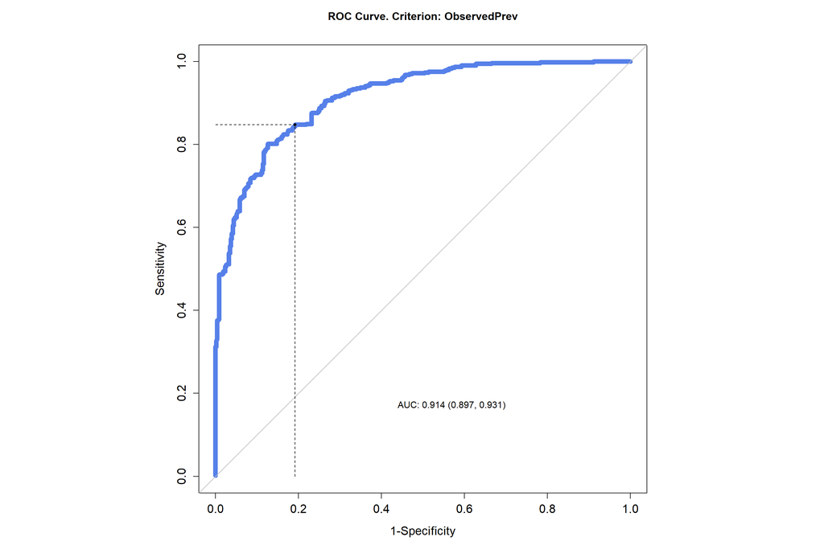

```r
######################################
# Creating a function to gather the
# classification metrics applying the
# threshold criterion using the point
# with closest value to observed prevalence
######################################
ClassificationMetrics.Class0.LO.OBSERVEDPREV <- function(SourceData,Response,Predictor){
  ThresholdCriterion <- optimal.cutpoints(X = Predictor,
                                         status = Response,
                                         tag.healthy = "Low",
                                         methods = c("ObservedPrev"),
                                         data = SourceData,
                                         pop.prev = NULL,
                                         ci.fit = FALSE,
                                         direction = c("<"))

  summary(ThresholdCriterion)
  (OptimalThreshold <- ThresholdCriterion$ObservedPrev$Global$optimal.cutoff$cutoff[1])
  (ThresholdSensitivity <- ThresholdCriterion$ObservedPrev$Global$optimal.cutoff$Se[,1][1])
  (ThresholdSpecificity <- ThresholdCriterion$ObservedPrev$Global$optimal.cutoff$Sp[,1][1])
  (ThresholdROCAUC <- ThresholdCriterion$ObservedPrev$Global$measures.acc$AUC[1])
  plot.optimal.cutpoints(ThresholdCriterion,
                         col=c("#5680E9"),
                         legend=FALSE,
                         which=1,
                         xlim=c(0,1),
                         ylim=c(0,1),
                         lwd=8)
  ClassificationMetricsList <-list(OptimalThreshold,
                                   ThresholdSensitivity,
                                   ThresholdSpecificity,
                                   ThresholdROCAUC)
  return(ClassificationMetricsList)
}

ClassificationMetrics.Class0.HI.OBSERVEDPREV <- function(SourceData,Response,Predictor){
  ThresholdCriterion <- optimal.cutpoints(X = Predictor,
                                         status = Response,
                                         tag.healthy = "Low",
                                         methods = c("ObservedPrev"),
                                         data = SourceData,
                                         pop.prev = NULL,
                                         ci.fit = FALSE,
                                         direction = c(">"))

  summary(ThresholdCriterion)
  (OptimalThreshold <- ThresholdCriterion$ObservedPrev$Global$optimal.cutoff$cutoff[1])
  (ThresholdSensitivity <- ThresholdCriterion$ObservedPrev$Global$optimal.cutoff$Se[,1][1])
  (ThresholdSpecificity <- ThresholdCriterion$ObservedPrev$Global$optimal.cutoff$Sp[,1][1])
  (ThresholdROCAUC <- ThresholdCriterion$ObservedPrev$Global$measures.acc$AUC[1])
  plot.optimal.cutpoints(ThresholdCriterion,
                         col=c("#5680E9"),
                         legend=FALSE,
                         which=1,
                         xlim=c(0,1),
                         ylim=c(0,1),
                         lwd=8)
  ClassificationMetricsList <-list(OptimalThreshold,
                                   ThresholdSensitivity,
                                   ThresholdSpecificity,
                                   ThresholdROCAUC)
  return(ClassificationMetricsList)
}

######################################
# Gather the classification metrics
######################################
OPTTH.List <- list()
THSEN.List <- list()
THSPE.List <- list()
THAUC.List <- list()
PREDI.List <- list()

for (i in 7:7) {
  Response.i  <- colnames(LR_Model_Predictions)[6]
  Predictor.i <- colnames(LR_Model_Predictions)[i]

  ClassificationMetrics.i <- ClassificationMetrics.Class0.LO.OBSERVEDPREV(LR_Model_Predictions,
                                                                    Response.i,
                                                                    Predictor.i)
  OPTTH.i <- as.numeric(as.character(sprintf(ClassificationMetrics.i[1],fmt='%#.5f')))
  THSEN.i <- as.numeric(as.character(sprintf(ClassificationMetrics.i[2],fmt='%#.5f')))
  THSPE.i <- as.numeric(as.character(sprintf(ClassificationMetrics.i[3],fmt='%#.5f')))
  THAUC.i <- as.numeric(as.character(sprintf(ClassificationMetrics.i[4],fmt='%#.5f')))

  PREDI.List <- append(PREDI.List,Predictor.i)
  OPTTH.List <- append(OPTTH.List,OPTTH.i)
  THSEN.List <- append(THSEN.List,THSEN.i)
  THSPE.List <- append(THSPE.List,THSPE.i)
  THAUC.List <- append(THAUC.List,THAUC.i)
}
```

```r
ClassificationMetrics.SUMMARY <- cbind(PREDI.List,
                                       THAUC.List,
                                       OPTTH.List,
                                       THSEN.List,
                                       THSPE.List
)

colnames(ClassificationMetrics.SUMMARY) <- c("Predictor",
                                             "ROCAUC",
                                             "OptimalThreshold.OBSERVEDPREV",
                                             "ApparentSensitivity",
                                             "ApparentSpecificity")

OBSERVEDPREV.SUMMARY <- as.data.frame(ClassificationMetrics.SUMMARY)
OBSERVEDPREV.SUMMARY$ROCAUC <- as.numeric(as.character(OBSERVEDPREV.SUMMARY$ROCAUC))
OBSERVEDPREV.SUMMARY$ApparentSensitivity <- as.numeric(as.character(OBSERVEDPREV.SUMMARY$ApparentSensitivity))
OBSERVEDPREV.SUMMARY$ApparentSpecificity <- as.numeric(as.character(OBSERVEDPREV.SUMMARY$ApparentSpecificity))

(OBSERVEDPREV.Threshold <- OBSERVEDPREV.SUMMARY$OptimalThreshold.OBSERVEDPREV)
```

```
## $OptimalThreshold.OBSERVEDPREV
## [1] 0.54821
```

```r
(OBSERVEDPREV.Sensitivity <- OBSERVEDPREV.SUMMARY$ApparentSensitivity)
```

```
## [1] 0.84733
```

```r
(OBSERVEDPREV.Specificity <- OBSERVEDPREV.SUMMARY$ApparentSpecificity)
```

```
## [1] 0.80796
```

## 1.6 Consolidated Findings

**[A]** The dichotomization threshold criteria which supported a generally optimal classification performance considering the relative weights of sensitivity and specificity by demonstrating the best and most consistent metrics are as follows:  
**[A.1]** **MaxProdSpSe** with Apparent Sensitivity = 0.80153, Apparent Specificity = 0.87354  
**[A.2]** **ROC01** with Apparent Sensitivity = 0.80153, Apparent Specificity = 0.87354  
**[A.3]** **Youden** with Apparent Sensitivity = 0.80153, Apparent Specificity = 0.87354  
**[A.4]** **MaxEfficiency** with Apparent Sensitivity = 0.80153, Apparent Specificity = 0.87354  
**[A.5]** **MaxKappa** with Apparent Sensitivity = 0.80153, Apparent Specificity = 0.87354  
**[B]** The dichotomization threshold criterion which supported a generally optimal classification performance considering the equal weights of sensitivity and specificity by demonstrating the best and most consistent metrics are as follows:  
**[B.1]** **SpEqualSe** with Apparent Sensitivity = 0.82634, Apparent Specificity = 0.82670  
**[C]** The dichotomization threshold criteria which supported a specifically optimal classification performance considering more weight on maintaining low false negative cases by demonstrating the best and most consistent metrics are as follows:  
**[C.1]** **MinValueSe** with Apparent Sensitivity = 0.90458, Apparent Specificity = 0.73536  
**[C.2]** **MinValueNPV** with Apparent Sensitivity = 0.94656, Apparent Specificity = 0.62763  
**[D]** The dichotomization threshold criteria which supported a specifically optimal classification performance considering more weight on maintaining low false positive cases by demonstrating the best and most consistent metrics are as follows:  
**[D.1]** **MinValueSp** with Apparent Sensitivity = 0.72710, Apparent Specificity = 0.90398  
**[D.2]** **MinValuePPV** with Apparent Sensitivity = 0.72710, Apparent Specificity = 0.90398

**Code Chunk | Output**

```r
##################################
# Consolidating all evaluation results
# using the sensitivity and specificity metrics
##################################
Criterion <- c('MinValueSe','MinValueSp','MaxProdSpSe','ROC01','SpEqualSe',
           'Youden','MaxEfficiency','Minimax','MaxDOR','MaxKappa',
           'MinValueNPV','MinValuePPV','NPVEqualPPV','MinPvalue','ObservedPrev',
           'MinValueSe','MinValueSp','MaxProdSpSe','ROC01','SpEqualSe',
           'Youden','MaxEfficiency','Minimax','MaxDOR','MaxKappa',
           'MinValueNPV','MinValuePPV','NPVEqualPPV','MinPvalue','ObservedPrev')

Set <- c(rep('Apparent Sensitivity',15),rep('Apparent Specificity',15))

ClassificationMetrics <- c(MINVALUESE.Sensitivity,MINVALUESP.Sensitivity,MAXPRODSPSE.Sensitivity,ROC01.Sensitivity,SPEQUALSE.Sensitivity,
                 YOUDEN.Sensitivity,MAXEFFICIENCY.Sensitivity,MINIMAX.Sensitivity,MAXDOR.Sensitivity,MAXKAPPA.Sensitivity,
                 MINVALUENPV.Sensitivity,MINVALUEPPV.Sensitivity,NPVEQUALPPV.Sensitivity,MINPVALUE.Sensitivity,OBSERVEDPREV.Sensitivity,
                 MINVALUESE.Specificity,MINVALUESP.Specificity,MAXPRODSPSE.Specificity,ROC01.Specificity,SPEQUALSE.Specificity,
                 YOUDEN.Specificity,MAXEFFICIENCY.Specificity,MINIMAX.Specificity,MAXDOR.Specificity,MAXKAPPA.Specificity,
                 MINVALUENPV.Specificity,MINVALUEPPV.Specificity,NPVEQUALPPV.Specificity,MINPVALUE.Specificity,OBSERVEDPREV.Specificity)

ClassificationMetrics_Summary <- as.data.frame(cbind(Criterion,Set,ClassificationMetrics))

ClassificationMetrics_Summary$ClassificationMetrics <- as.numeric(as.character(ClassificationMetrics_Summary$ClassificationMetrics))
ClassificationMetrics_Summary$Set <- factor(ClassificationMetrics_Summary$Set,
                                        levels = c("Apparent Sensitivity",
                                                   "Apparent Specificity"))
ClassificationMetrics_Summary$Criterion <- factor(ClassificationMetrics_Summary$Criterion,
                                        levels = c('MinValueSe',
                                                   'MinValueSp',
                                                   'MaxProdSpSe',
                                                   'ROC01',
                                                   'SpEqualSe',
                                                   'Youden',
                                                   'MaxEfficiency',
                                                   'Minimax',
                                                   'MaxDOR',
                                                   'MaxKappa',
                                                   'MinValueNPV',
                                                   'MinValuePPV',
                                                   'NPVEqualPPV',
                                                   'MinPvalue',
                                                   'ObservedPrev'))

print(ClassificationMetrics_Summary, row.names=FALSE)
```

```
##      Criterion                  Set ClassificationMetrics
##     MinValueSe Apparent Sensitivity               0.90458
##     MinValueSp Apparent Sensitivity               0.72710
##    MaxProdSpSe Apparent Sensitivity               0.80153
##          ROC01 Apparent Sensitivity               0.80153
##      SpEqualSe Apparent Sensitivity               0.82634
##         Youden Apparent Sensitivity               0.80153
##  MaxEfficiency Apparent Sensitivity               0.80153
##        Minimax Apparent Sensitivity               0.84351
##         MaxDOR Apparent Sensitivity               0.31298
##       MaxKappa Apparent Sensitivity               0.80153
##    MinValueNPV Apparent Sensitivity               0.94656
##    MinValuePPV Apparent Sensitivity               0.72710
##    NPVEqualPPV Apparent Sensitivity               0.86260
##      MinPvalue Apparent Sensitivity               1.00000
##   ObservedPrev Apparent Sensitivity               0.84733
##     MinValueSe Apparent Specificity               0.73536
##     MinValueSp Apparent Specificity               0.90398
##    MaxProdSpSe Apparent Specificity               0.87354
##          ROC01 Apparent Specificity               0.87354
##      SpEqualSe Apparent Specificity               0.82670
##         Youden Apparent Specificity               0.87354
##  MaxEfficiency Apparent Specificity               0.87354
##        Minimax Apparent Specificity               0.81030
##         MaxDOR Apparent Specificity               1.00000
##       MaxKappa Apparent Specificity               0.87354
##    MinValueNPV Apparent Specificity               0.62763
##    MinValuePPV Apparent Specificity               0.90398
##    NPVEqualPPV Apparent Specificity               0.76815
##      MinPvalue Apparent Specificity               0.08431
##   ObservedPrev Apparent Specificity               0.80796
```

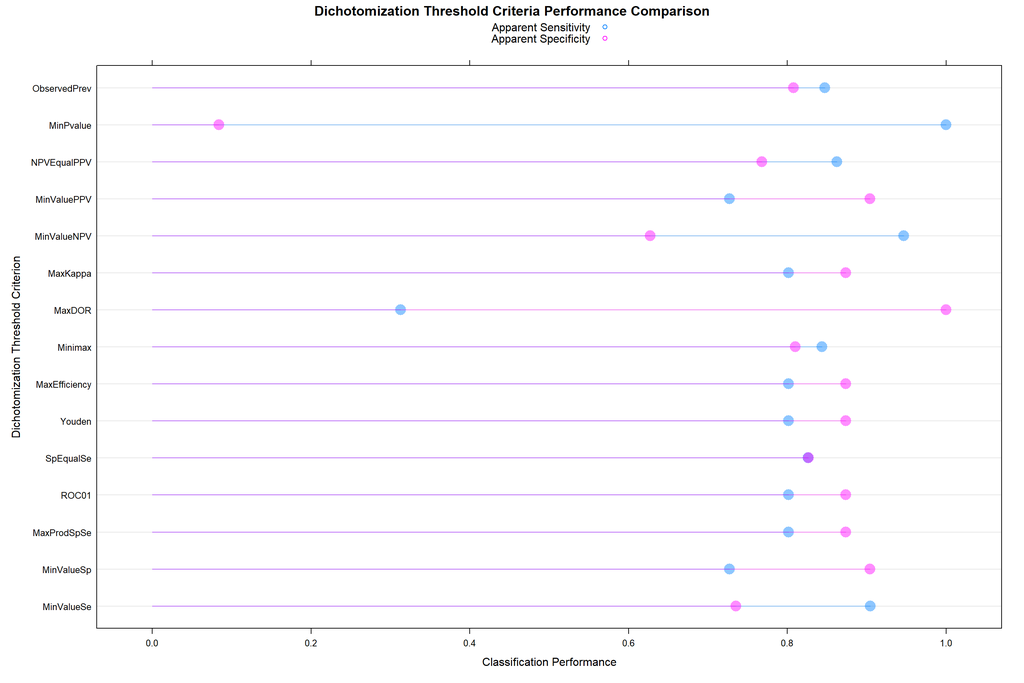

```r
(ClassificationMetrics_Plot <- dotplot(Criterion ~ ClassificationMetrics,
                           data = ClassificationMetrics_Summary,
                           groups = Set,
                           main = "Dichotomization Threshold Criteria Performance Comparison",
                           ylab = "Dichotomization Threshold Criterion",
                           xlab = "Classification Performance",
                           auto.key = list(adj = 1),
                           type=c("p", "h"),
                           origin = 0,
                           alpha = 0.45,
                           pch = 16,
                           cex = 2))
```

# **2. Summary**

[figure not shown]

# **3. References**

**[Book]** [Applied Predictive Modeling](http://appliedpredictivemodeling.com/) by Max Kuhn and Kjell Johnson  
**[Book]** [An Introduction to Statistical Learning](https://www.statlearning.com/) by Gareth James, Daniela Witten, Trevor Hastie and Rob Tibshirani  
**[Book]** [Multivariate Data Visualization with R](http://lmdvr.r-forge.r-project.org/figures/figures.html) by Deepayan Sarkar  
**[Book]** [Machine Learning](https://bookdown.org/ssjackson300/Machine-Learning-Lecture-Notes/) by Samuel Jackson  
**[Book]** [Data Modeling Methods](https://bookdown.org/larget_jacob/data-modeling-methods/) by Jacob Larget  
**[Book]** [Introduction to R and Statistics](https://saestatsteaching.tech/) by University of Western Australia  
**[Book]** [Feature Engineering and Selection: A Practical Approach for Predictive Models](http://www.feat.engineering/index.html) by Max Kuhn and Kjell Johnson  
**[Book]** [Introduction to Research Methods](https://bookdown.org/ejvanholm/Textbook/) by Eric van Holm  
**[R Package]** [AppliedPredictiveModeling](https://cran.r-project.org/web//packages/AppliedPredictiveModeling/AppliedPredictiveModeling.pdf) by Max Kuhn  
**[R Package]** [caret](https://topepo.github.io/caret/index.html) by Max Kuhn  
**[R Package]** [rpart](https://mran.microsoft.com/web/packages/rpart/rpart.pdf) by Terry Therneau and Beth Atkinson  
**[R Package]** [lattice](https://cran.r-project.org/web/packages/lattice/lattice.pdf) by Deepayan Sarkar  
**[R Package]** [dplyr](https://cran.r-project.org/web/packages/dplyr/index.html/) by Hadley Wickham  
**[R Package]** [moments](https://cran.r-project.org/web/packages/moments/index.html) by Lukasz Komsta and Frederick  
**[R Package]** [skimr](https://cran.r-project.org/web/packages/skimr/skimr.pdf) by Elin Waring  
**[R Package]** [RANN](https://cran.r-project.org/web/packages/RANN/RANN.pdf) by Sunil Arya, David Mount, Samuel Kemp and Gregory Jefferis  
**[R Package]** [corrplot](https://cran.r-project.org/web/packages/corrplot/corrplot.pdf) by Taiyun Wei  
**[R Package]** [tidyverse](https://cran.r-project.org/web/packages/tidyverse/tidyverse.pdf) by Hadley Wickham  
**[R Package]** [lares](https://cran.rstudio.com/web/packages/lares/lares.pdf) by Bernardo Lares  
**[R Package]** [DMwR](https://mran.microsoft.com/snapshot/2016-05-02/web/packages/DMwR/DMwR.pdf) by Luis Torgo  
**[R Package]** [gridExtra](https://cran.r-project.org/web/packages/gridExtra/gridExtra.pdf) by Baptiste Auguie and Anton Antonov  
**[R Package]** [rattle](https://cran.r-project.org/web/packages/rattle/rattle.pdf) by Graham Williams  
**[R Package]** [rpart.plot](https://cran.r-project.org/web/packages/rpart.plot/rpart.plot.pdf) by Stephen Milborrow  
**[R Package]** [RColorBrewer](https://cran.r-project.org/web//packages/RColorBrewer/RColorBrewer.pdf) by Erich Neuwirth  
**[R Package]** [stats](https://search.r-project.org/R/refmans/stats/html/00Index.html) by R Core Team  
**[R Package]** [pls](https://cran.r-project.org/web/packages/pls/pls.pdf) by Kristian Hovde Liland  
**[R Package]** [nnet](https://cran.r-project.org/web/packages/nnet/nnet.pdf) by Brian Ripley  
**[R Package]** [elasticnet](https://cran.r-project.org/web/packages/elasticnet/elasticnet.pdf) by Hui Zou  
**[R Package]** [earth](https://cran.r-project.org/web/packages/earth/earth.pdf) by Stephen Milborrow  
**[R Package]** [party](https://cran.r-project.org/web/packages/party/party.pdf) by Torsten Hothorn  
**[R Package]** [kernlab](https://cran.r-project.org/web/packages/kernlab/kernlab.pdf) by Alexandros Karatzoglou  
**[R Package]** [randomForest](https://cran.r-project.org/web/packages/randomForest/randomForest.pdf) by Andy Liaw  
**[R Package]** [pROC](https://cran.r-project.org/web/packages/pROC/pROC.pdf) by Xavier Robin  
**[R Package]** [mda](https://cran.r-project.org/web/packages/mda/mda.pdf) by Trevor Hastie  
**[R Package]** [klaR](https://cran.r-project.org/web/packages/klaR/klaR.pdf) by Christian Roever, Nils Raabe, Karsten Luebke, Uwe Ligges, Gero Szepannek, Marc Zentgraf and David Meyer  
**[R Package]** [pamr](https://cran.r-project.org/web/packages/pamr/pamr.pdf) by Trevor Hastie, Rob Tibshirani, Balasubramanian Narasimhan and Gil Chu  
**[R Package]** [OptimalCutpoints](https://cran.r-project.org/web/packages/OptimalCutpoints/OptimalCutpoints.pdf) by Monica Lopez-Raton and Maria Xose Rodriguez-Alvarez  
**[R Package]** [broom](https://cran.r-project.org/web/packages/broom/broom.pdf) by Simon Couch  
**[R Package]** [PRROC](https://cran.r-project.org/web/packages/PRROC/PRROC.pdf) by Jan Grau and Jens Keilwagen  
**[Article]** [The caret Package](https://topepo.github.io/caret/index.html) by Max Kuhn  
**[Article]** [A Short Introduction to the caret Package](https://cran.r-project.org/web/packages/caret/vignettes/caret.html) by Max Kuhn  
**[Article]** Caret Package – A Practical Guide to Machine Learning in R by Selva Prabhakaran  
**[Article]** [Tuning Machine Learning Models Using the Caret R Package](https://machinelearningmastery.com/tuning-machine-learning-models-using-the-caret-r-package/) by Jason Brownlee  
**[Article]** [Lattice Graphs](http://www.sthda.com/english/wiki/lattice-graphs) by Alboukadel Kassambara  
**[Article]** [How to Select the Best Cutoff Point for the Problem Using ROC AUC Curve in R](https://www.projectpro.io/recipes/select-best-cutoff-point-for-problem-roc-auc-curve-r#mcetoc_1g4q3v8dnk) by Gautam Vermani  
**[Article]** [Obtain Optimal Probability Threshold Using ROC](https://www.kaggle.com/code/nicholasgah/obtain-optimal-probability-threshold-using-roc) by Nicholas Law  
**[Article]** [Beginners Guide To Understanding ROC Curve: How To Find The Perfect Probability Threshold](https://analyticsindiamag.com/beginners-guide-to-understanding-roc-curve-how-to-find-the-perfect-probability-threshold/) by Amal Nair  
**[Article]** [ROC Curve](https://devopedia.org/roc-curve) by Devopedia Org Team  
**[Article]** [ROC Curves – What Are They and How Are They Used?](https://acutecaretesting.org/en/articles/roc-curves-what-are-they-and-how-are-they-used) by Suzanne Ekelund  
**[Article]** [Assessing and Comparing Classifier Performance with ROC Curves](https://machinelearningmastery.com/assessing-comparing-classifier-performance-roc-curves-2/) by Jason Brownlee  
**[Article]** [What is a ROC Curve, and How Do You Use It in Performance Modeling?](https://www.simplilearn.com/what-is-a-roc-curve-and-how-to-use-it-in-performance-modeling-article) by John Terra  
**[Article]** [AUC-ROC Curve](https://www.geeksforgeeks.org/auc-roc-curve/) by Geeks For Geeks Team  
**[Article]** [Discrimination Threshold](https://www.scikit-yb.org/en/latest/api/classifier/threshold.html) by Scikit-Learn Team  
**[Article]** [How to Interpret a ROC Curve (With Examples)](https://www.statology.org/interpret-roc-curve/) by Statology Team  
**[Article]** [Evaluation of Classification Model Accuracy](http://www.sthda.com/english/articles/36-classification-methods-essentials/143-evaluation-of-classification-model-accuracy-essentials/) by Alboukadel Kassambara  
**[Publication]** [The Origins of Logistic Regression](http://dx.doi.org/10.2139/ssrn.360300) by JS Cramer (Econometrics eJournal)  
**[Publication]** [Constructing a Cut-off Point for a Quantitative Diagnostic Test](https://onlinelibrary.wiley.com/doi/10.1002/sim.4780081110) by Helmut Schaefer (Statistics in Medicine)  
**[Publication]** [Use of the Noninvasive Components of the Mayo Score to Assess Clinical Response in Ulcerative Colitis](https://academic.oup.com/ibdjournal/article/14/12/1660/4654949) by James Lewis, Shaokun Chuai, Lisa Nessel, Gary Lichtenstein, Faten Aberra and Jonas Ellenberg (Inflammatory Bowel Diseases)  
**[Publication]** [Basic Principles of ROC Analysis](https://www.sciencedirect.com/science/article/abs/pii/S0001299878800142?via%3Dihub) by Charles Metz (Seminars in Nuclear Medicine)  
**[Publication]** [Two-Graph Receiver Operating Characteristic (TG-ROC): a Microsoft-EXCEL Template for the Selection of Cut-off Values in Diagnostic Tests](https://www.sciencedirect.com/science/article/abs/pii/002217599500078O) by Matthias Greiner (Journal of Immunological Methods)  
**[Publication]** [Index for Rating Diagnostic Tests](https://acsjournals.onlinelibrary.wiley.com/doi/pdf/10.1002/1097-0142%281950%293%3A1%3C32%3A%3AAID-CNCR2820030106%3E3.0.CO%3B2-3) by William Youden (Cancer)  
**[Publication]** [The Accuracy of Diver Sound Localization by Pointing](https://europepmc.org/article/MED/15622737) by Stephen Feinstein (Undersea Biomedical Research)  
**[Publication]** [Screening Versus Prevalence Estimation](https://www.jstor.org/stable/2347839?origin=crossref) by David Hand (Applied Statistics)  
**[Publication]** [Risk Ratios, Odds Ratio and the Test QROC](https://us.sagepub.com/en-us/nam/evaluating-medical-tests/book3306) by Helena Kraemer (SAGE Publications)  
**[Publication]** [A Coefficient of Agreement for Nominal Scales](https://journals.sagepub.com/doi/10.1177/001316446002000104) by Jacob Cohen (Educational Psychology Measurement)  
**[Publication]** [Strategies for Graphical Threshold Determination](https://www.sciencedirect.com/science/article/abs/pii/0169260791900722?via%3Dihub) by Jean Vermont (Computer Methods and Programs in Biomedicine)  
**[Publication]** [Maximally Selected Chi-Square Statistics](https://www.jstor.org/stable/2529881?origin=crossref) by Rupert Miller and David Siegmund (Biometrics)  
**[Publication]** [Evaluating Presence-Absence Models in Ecology: The Need to Account for Prevalence](https://besjournals.onlinelibrary.wiley.com/doi/full/10.1046/j.1365-2664.2001.00647.x) by Stephanie Manel (Journal of Applied Ecology)  
**[Course]** [Applied Data Mining and Statistical Learning](https://online.stat.psu.edu/stat508/) by Penn State Eberly College of Science